ANGIUS Marco and AVALLE Giorgio - Ⓒ2018

# Estimating Financial Risk through Monte Carlo Simulation

Risk analysis is part of every decision we make when faced with uncertainty, ambiguity, and variability. Indeed, even though we have unprecedented access to information, we can't accurately predict the future. In finance, there is a fair amount of uncertainty and risk involved with estimating the future value of financial products, due to the wide variety of potential outcomes. Monte Carlo simulation (also known as the Monte Carlo Method) allows inspecting many possible outcomes of the decision making process, and can be used to assess the impact of risk: this, in turns, allows for better decision-making under uncertainty.

## Goals

The main objectives we set for this Notebook are as follows:

1. Develop fundamental knowledge about Risk analysis
2. Understand Monte Carlo Simulation (MCS)
3. Apply Monte Carlo Simulation for predicting risk

## Steps

1. First, in section 1, we introduce the basics of MCS
2. In section 2, we work on a simple example to where we apply the MCS method
3. In section 3, we briefly summarize the main characteristics of the Monte Carlo Simulation (MCS) technique
4. In section 4, we overview the common distributions which are often used in MCS
5. In section 5, we work on a real use case, that focuses on estimating financial risk. We will use techniques such as featurization (that is, generating additional features to improve model accuracy), linear regression, kernel density estimation, sampling distributions and so on ...

## Reference

This Notebook is inspired by Chapter 9 of the book [Advanced Analytics with Spark](http://shop.oreilly.com/product/0636920035091.do) by Josh Wills, Sandy Ryza, Sean Owen, and Uri Laserson. It is strongly suggested to read this Chapter to get a general idea of the topic of this Notebook.

# 1. Introduction

## 1.1. Monte Carlo Simulation (MCS)

Monte Carlo simulation is a computerized mathematical technique that can be applied such that it is possible to account for risk in quantitative analysis and decision making. This technique is used in many different fields, such as R&D, risk management, portfolio management, pricing derivatives, strategic planning, project planning, cost modeling and many more.

In general, MCS is a technique that "converts" uncertainty on input variables of a model into **probability distributions**. By combining the distributions and randomly selecting values from them, it recalculates the simulated model many times, to determine the probability of the output.

Historically, this technique was first used by scientists working on the atomic bomb: it was named after Monte Carlo, the Monaco resort town renowned for its casinos. Since its introduction in World War II, Monte Carlo simulation has been used to model a variety of physical and conceptual systems.

## 1.2. How does it work?

Monte Carlo simulation performs risk analysis by building models of possible results by *substituting a range of possible input values, that constitute uncertainty, into a statistical distribution*. It then computes possible outcomes repeatedly, each time using a different set of random values from the probability functions that "model" the input. Depending upon the number of random input variables and their distribution, a Monte Carlo simulation could involve thousands or tens of thousands of "rounds" before it is complete. When complete, *Monte Carlo simulation produces distributions of possible outcome values*.

By using probability distributions instead of actual input samples, it is possible to model more accurately uncertainty: different choices of distributions will yield different outputs.

# 2. Illustrative example

Imagine you are the marketing manager for a firm that is planning to introduce a new product. You need to estimate the first-year net profit from this product, which might depend on:

- Sales volume in units
- Price per unit (also called "Selling price")
- Unit cost
- Fixed costs

Net profit will be calculated as $Net Profit = Sales Volume* (Selling Price - Unit cost) - Fixed costs$. Fixed costs (accounting for various overheads, advertising budget, etc.) are known to be \$ 120,000, which we assume to be deterministic. All other factors, instead, involve some uncertainty: *sales volume* (in units) can cover quite a large range, the *selling price* per unit will depend on competitor actions, which are hard to predict, and *unit costs* will also vary depending on vendor prices and production experience, for example.

Now, to build a risk analysis model, we must first identify the uncertain variables -- which are essentially random variables. While there's some uncertainty in almost all variables in a business model, we want to focus on variables where the range of values is significant.

## 2.1. Unit sales and unit price

Based on a hypothetical market research you have done, you have beliefs that there are equal chances for the market to be `slow`, `normal`, or `hot`:

- In a "slow" market, you expect to sell 50,000 units at an average selling price of \$11.00 per unit
- In a "normal" market, you expect to sell 75,000 units, but you'll likely realize a lower average selling price of \$10.00 per unit
- In a "hot" market, you expect to sell 100,000 units, but this will bring in competitors, who will drive down the average selling price to \$8.00 per unit

### Question 1

Calculate the average units and the unit price that you expect to sell, which depend on the market state. Use the assumptions above to compute the expected quantity of products and their expected unit price.

```python
average_unit = ( 50000 + 75000 + 100000 ) / 3
average_price = ( 11.00 + 10.00 + 8.00 ) / 3
print("average unit: {0:,.0f}".format(average_unit))
print("average price: {0:.3f}".format(average_price))
```

```
average unit: 75,000
average price: 9.667
```

## 2.2. Unit Cost

Another uncertain variable is Unit Cost. In our illustrative example, we assume that your firm's production manager advises you that unit costs may be anywhere from \$5.50 to \$7.50, with a most likely expected cost of \$6.50. In this case, the most likely cost can be considered as the average cost.

## 2.3. A Flawed Model: using averages to represent our random variables

Our next step is to identify uncertain functions -- also called functions of a random variable. Recall that Net Profit is calculated as $Net Profit = Sales Volume * (Selling Price - Unit cost) - Fixed costs$. However, Sales Volume, Selling Price and Unit Cost are all uncertain variables, so Net Profit is an uncertain function.

The simplest model to predict the Net Profit is using average of sales volume, average of selling price and average of unit cost for calculating. So, if only consider averages, we can say that the $Net Profit = 75,000*(9.66666666 - 6.5) - 120,000 \sim 117,500$.

However, as [Dr. Sam Savage](http://web.stanford.edu/~savage/faculty/savage/) warns, "Plans based on average assumptions will be wrong on average." The calculated result is far from the actual value: indeed, the **true average Net Profit** is roughly \$93,000, as we will see later in the example.

### Question 2

#### Question 2.1

Write a function named `calNetProfit` to calculate the Net Profit using the average of sales volume, the average of selling price and the average of unit cost.

```python
def calNetProfit(average_unit, average_price, average_unitcost, fixed_cost):
    return average_unit * ( average_price - average_unitcost ) - fixed_cost

average_unitcost = 6.50
fixed_cost = 120000
net_profit = calNetProfit(average_unit, average_price, average_unitcost, fixed_cost)
print("Net profit: {0:,.0f}".format(net_profit))
```

```
Net profit: 117,500
```

#### Question 2.2

Verify the warning message of Dr. Sam Savage by calculating the error of our estimated Net Profit using averages only. Recall that the true value is roughly \$93,000, so we are interested in:

$$ error = \frac{your\_value - true\_value}{true\_value}$$

Note also we are interested in displaying the error as a percentage.

Looking at the error we make, do you think that we can use the current model that only relies on averages?

```python
def profitError(net_profit: int, true_net_profit: int):
    """
    Function to compute the error of the predicted profit given the true and the predicted one.

    Params:
        netProfit: (int) -> the Net Profit predicted
        trueNetProfit (int) -> the true Net Profit to compute the error
    """

    return ( net_profit - true_net_profit ) / (true_net_profit)
```

```python
true_net_profit = 93000
error = profitError( net_profit, true_net_profit )
print("Error in percentage: {0:.2f}%".format( error * 100 ))
```

```
Error in percentage: 26.34%
```

### Comment

We cannot use such model because the risk is too high. Indeed we do not have any confidence level over the estimated value to really make a decision. In finance, as for many other sectors, take a decision involves money. We need a method able to let us know how confident we are on the estimated results, so that we can decide if we really want to take the risk.

## 2.4. Using the Monte Carlo Simulation method to improve our model

As discussed before, the selling price and selling volume both depend on the state of the market scenario (slow/normal/hot). So, the net profit is the result of two random variables: `market scenario` (which in turn determines `sales volumes` and `selling price`) and `unit cost`.

Now, let's assume (this is an *a-priori* assumption we make) that `market scenario` follows a discrete, uniform distribution and that `unit cost` also follows a uniform distribution. Then, we can compute directly the values for selling price and selling volumes based on the outcome of the random variable `market scenario`, as shown in Section 2.1.

From these a-priori distributions, in each run (or trial) of our Monte Carlo simulation, we can generate the sample value for each random variable and use it to calculate the Net Profit. The more simulation runs, the more accurate our results will be. For example, if we run the simulation 100,000 times, the average net profit will amount to roughly \$92,600. Every time we run the simulation, a different prediction will be output: the average of such predictions will consistently be less than \$117,500, which we predicted using averages only.

Note also that in this simple example, we generate values for the `market scenario` and `unit cost` independently: we consider them to be **independent random variables**. This means that the eventual (and realistic!) correlation between the `market scenario` and `unit cost` variables is ignored. Later, we will learn how to be more precise and account for dependency between random variables.

### Question 3

#### Question 3.1

Write a function named `get_sales_volume_price` that returns the sales volume and price based on the market scenario. In particular, the scenario can get one of three values:

- 0: Slow market
- 1: Normal market
- 2: Hot market

The return value is a tuple in the form: `(sales_volume, price)`

```python
# Get sales volume and  price based on market scenario
# the function returns a tuple of (sales_volume, price)
def getSalesVolumePrice(scenario):
    # Slow market
    if scenario == 0:
        return ( 50000, 11.00 )
    # Normal market
    if scenario == 1:
        return ( 75000, 10.00 )
    # Hot market
    if scenario == 2:
        return ( 100000, 8.00 )
```

#### Question 3.2

Run 100,000 Monte Carlo simulations and calculate the average net profit they produce. Then, compare the result to the "average model" we used in the previous questions (the one we called "flawed" model). Put your comments about the discrepancies between a simplistic model, and the more accurate MCS approach.

Note that in each iteration, the `unit_cost` and `market_scenario` are generated according to their distributions. Also, recall what we have seen in Section 2.2: your firm account manager helped you with some research, to determine the variability of your random variables.

HINT

Function `uniform(a,b)` in module `random` generates a number $a<=c<=b$, which is drawn from a uniform distribution.

Function `randint(a,b)` helps you generating an integer number $a<=c<=b$

```python
from random import uniform, randint

def monteCarloSim(num_simulation: int):
    """
    Simple Monte Carlo simulation function to compute the average of the profit produced given certain conditions.
    Conditions: different markets modelled as uniform distributed and unit costs uniform distributed between 5.50$ to 7.50$

    Params:
        num_simulation (int) -> used to decide the number of "Runs" for the Monte Carlo Simulation
    """

    total = 0.0
    for i in range(0,num_simulation):
        # the unit cost is generated uniform between the values suggested above
        unit_cost = uniform( 5.50, 7.50 )
        # we generate the possible market scenario which ranges between 0 and 2 (values of our function)
        market_scenario = randint( 0, 2 )
        sales_volume, price = getSalesVolumePrice(market_scenario)
        # we use the above defined function with the fixed_cost as the one proposed before
        net_profit = calNetProfit(sales_volume, price, unit_cost, fixed_cost)
        total += net_profit
    return total
```

```python
num_simulation = 100000
total = monteCarloSim( num_simulation )

print("average net profit: {0:,.0f}".format( total / num_simulation ) )
```

```
average net profit: 92,739
```

```python
# we run several estimation to compute the average error for our estimation using the Monte Carlo Simualtion
from numpy import average

num_trials = 10
num_simulation = 100000
results = []

for sim in range(num_trials):
    results.append( monteCarloSim(num_simulation) / num_simulation )

# compute the average calling the numpy function
average_net_profit = average(results)
print("average net profit after {0!s} trials : {1:,.0f}".format( num_trials, average_net_profit ))
```

```
average net profit after 10 trials : 92,426
```

```python
# we compute the error on the average for the Monte Carlo Simulation
error = profitError(average_net_profit, true_net_profit )
print("Error in percentage: {0:.2f}%".format( error * 100))
```

```
Error in percentage: -0.62%
```

### Comment

The **Monte Carlo Simulation** has proven to produce a result whose average error in evaluating the profit is closer to 0. If compared with the previous result from the *flowed model*, the Monte Carlo one is far better.  
Even if we obtained a better result, we have not been able yet to provide a confidence interval for the predicted value. Also, we supported the MCS with some a priori information such as the *variable costs* (or unitary costs) and the *market scenario* distributions.

# 3. A brief summary of the Monte Carlo Simulation (MCS) technique

- A MCS allows several inputs to be used at the same time to compute the probability distribution of one or more outputs
- Different types of probability distributions can be assigned to the inputs of the model, depending on any *a-priori* information that is available. When the distribution is completely unknown, a common technique is to use a distribution computed by finding the best fit to the data you have
- The MCS method is also called a **stochastic method** because it uses random variables. Note also that the general assumption is for input random variables to be independent from each other. When this is not the case, there are techniques to account for correlation between random variables.
- A MCS generates the output as a range instead of a fixed value and shows how likely the output value is to occur in that range. In other words, the model outputs a probability distribution.

# 4. Common distributions used in MCS

In what follows, we summarize the most common probability distributions that are used as *a-priori* distributions for input random variables:

- *Normal/Gaussian Distribution*: this is a continuous distribution applied in situations where the mean and the standard deviation of a given input variable are given, and the mean represents the most probable value of the variable. In other words, values "near" the mean are most likely to occur. This is symmetric distribution, and it is not bounded in its co-domain. It is very often used to describe natural phenomena, such as people’s heights, inflation rates, energy prices, and so on and so forth. An illustration of a normal distribution is given below:

[figure not shown]

- *Lognormal Distribution*: this is a distribution which is appropriate for variables taking values in the range $[0, \infty]$. Values are positively skewed, not symmetric like a normal distribution. Examples of variables described by some lognormal distributions include, for example, real estate property values, stock prices, and oil reserves. An illustration of a lognormal distribution is given below:

[figure not shown]

- *Triangular Distribution*: this is a continuous distribution with fixed minimum and maximum values. It is bounded by the minimum and maximum values and can be either symmetrical (the most probable value = mean = median) or asymmetrical. Values around the most likely value (e.g. the mean) are more likely to occur. Variables that could be described by a triangular distribution include, for example, past sales history per unit of time and inventory levels. An illustration of a triangular distribution is given below:

[figure not shown]

- *Uniform Distribution*: this is a continuous distribution bounded by known minimum and maximum values. In contrast to the triangular distribution, the likelihood of occurrence of the values between the minimum and maximum is the same. In other words, all values have an equal chance of occurring, and the distribution is simply characterized by the minimum and maximum values. Examples of variables that can be described by a uniform distribution include manufacturing costs or future sales revenues for a new product. An illustration of the uniform distribution is given below:

[figure not shown]

- *Exponential Distribution*: this is a continuous distribution used to model the time that pass between independent occurrences, provided that the rate of occurrences is known. An example of the exponential distribution is given below:

[figure not shown]

- *Discrete Distribution* : for this kind of distribution, the "user" defines specific values that may occur and the likelihood of each of them. An example might be the results of a lawsuit: 20% chance of positive verdict, 30% change of negative verdict, 40% chance of settlement, and 10% chance of mistrial.

# 5. A real use case: estimating the financial risk of a portfolio of stocks

We hope that by now you have a good understanding about Monte Carlo simulation. Next, we apply this method to a real use case: *financial risk estimation*.

Imagine that you are an investor on the stock market. You plan to buy some stocks and you want to estimate the maximum loss you could incur after two weeks of investing. This is the quantity that the financial statistic "Value at Risk" (VaR) seeks to measure. [VaR](https://en.wikipedia.org/wiki/Value_at_risk) is defined as a measure of investment risk that can be used as a reasonable estimate of the maximum probable loss for a value of an investment portfolio, over a particular time period. A VaR statistic depends on three parameters: a portfolio, a time period, and a confidence level. A VaR of 1 million dollars with a 95% confidence level over two weeks, indicates the belief that the portfolio stands only a 5% chance of losing more than 1 million dollars over two weeks. VaR has seen widespread use across financial services organizations. This statistic plays a vital role in determining how much cash investors must hold to meet the credit ratings that they seek. In addition, it is also used to understand the risk characteristics of large portfolios: it is a good idea to compute the VaR before executing trades, such that it can help take informed decisions about investments.

Our goal is calculating VaR of two weeks interval with 95% confidence level and the associated [VaR confidence interval](http://www.investopedia.com/ask/answers/041615/whats-difference-between-confidence-level-and-confidence-interval-value-risk-var.asp).

## 5.1. Terminology

In this use case, we will use some terms that might require a proper definition, given the domain. This is what we call the *Domain Knowledge*.

- **Instrument**: A tradable asset, such as a bond, loan, option, or stock investment. At any particular time, an instrument is considered to have a value, which is the price for which it can be sold. In the use case of this notebook, instruments are stock investments.
- **Portfolio**: A collection of instruments owned by a financial institution.
- **Return**: The change in an instrument or portfolio’s value over a time period.
- **Loss**: A negative return.
- **Index**: An imaginary portfolio of instruments. For example, the NASDAQ Composite index includes about 3,000 stocks and similar instruments for major US and international companies.
- **Market factor**: A value that can be used as an indicator of macro aspects of the financial climate at a particular time. For example, the value of an index, the Gross Domestic Product of the United States, or the exchange rate between the dollar and the euro. We will often refer to market factors as just factors.

## 5.2. The context of our use case

We have a list of instruments that we plan to invest in. The historical data of each instrument has been collected for you. For simplicity, assume that the returns of instruments at a given time, depend on 4 market factors only:

- GSPC value
- IXIC value
- The return of crude oil
- The return of treasury bonds

Our goal is building a model to predict the loss after two weeks' time interval with confidence level set to 95%.

As a side note, it is important to realize that the approach presented in this Notebook is a simplified version of what would happen in a real Financial firm. For example, the returns of instruments at a given time often depend on more than 4 market factors only! Moreover, the choice of what constitute an appropriate market factor is an art!

## 5.3. The Data

The stock data can be downloaded (or scraped) from Yahoo! by making a series of REST calls. The data includes multiple files. Each file contains the historical information of each instrument that we want to invest in. The data is in the following format (with some samples):

```
Date, Open, High, Low, Close, Volume, Adj Close
2016-01-22,66.239998,68.07,65.449997,67.860001,137400,67.860001
2016-01-21,65.410004,66.18,64.459999,65.050003,148000,65.050003
2016-01-20,64.279999,66.32,62.77,65.389999,141300,65.389999
2016-01-19,67.720001,67.989998,64.720001,65.379997,178400,65.379997
```

The data of GSPC and IXIC values (our two first market factors) are also available on Yahoo! and use the very same format.

The crude oil and treasure bonds data is collected from investing.com, and has a different format, as shown below (with some samples):

```
Date    Price   Open    High    Low     Vol.    Change %
Jan 25, 2016    32.17   32.36   32.44   32.10   -       -0.59%
Jan 24, 2016    32.37   32.10   32.62   31.99   -       0.54%
Jan 22, 2016    32.19   29.84   32.35   29.53   -       9.01%
Jan 21, 2016    29.53   28.35   30.25   27.87   694.04K 11.22%
Jan 20, 2016    26.55   28.33   28.58   26.19   32.11K  -6.71%
Jan 19, 2016    28.46   29.20   30.21   28.21   188.03K -5.21%
```

In our use case, the factors' data will be used jointly to build a statistical model: as a consequence, we first need to preprocess the data to proceed.

## 5.4. Data preprocessing

In this Notebook, all data files have been downloaded for you, such that you can focus on pre-processing. Next, we will:

- Read the factor data files which are in two different formats, process and merge them together
- Read the stock data and pre-process it
- Trim all data into a specific time region
- Fill in the missing values
- Generate the data of returns in each two weeks' time interval window

### Factor data pre-processing

We need two functions to read and parse data from Yahoo! and Investing.com respectively. We are interested only in information about the time and the corresponding returns of a factor or an instrument: as a consequence, we will project away many columns of our RAW data, and keep only the information we are interested in.

The 3000-instrument and the 4-factor history are small enough to be read and processed locally: we do not need to use the power of parallel computing to proceed. Note that this is true also for larger cases with hundreds of thousands of instruments and thousands of factors. The need for a distributed system like Spark comes in when actually **running** the Monte Carlo simulations, which can require massive amounts of computation on each instrument.

### Question 4

#### Question 4.1

Write a function named `readInvestingDotComHistory` to parse data from investing.com based on the format specified above (see Section 5.3). Recall that we use two factors here: one that is related to the price of crude oil, one that is related to some specific US bonds.

Print the first 5 entries of the first factor (crude oil price) in the parsed data.

Note that we are only interested in the date and price of stocks.

HINT

You can parse a string to `datetime` object by using the function `strptime(<string>, <dtime_format>)`. In this case, the datetime format is `"%b %d, %Y"`. For more information, please follow this [link](https://docs.python.org/2/library/datetime.html#strftime-and-strptime-behavior).

In the next cell, we simply copy data from our HDFS cluster (that contains everything we need for this Notebook) to the instance (a Docker container) running your Notebook. This means that you will have "local" data that you can process without using Spark. Note the folder location: find and verify that you have correctly downloaded the files!

```python
! [ -d monte-carlo-risk ] || (echo "Downloading prepared data from HDFS. Please wait..." ; hdfs dfs -copyToLocal /datasets/monte-carlo-risk . ; echo "Done!";)
```

```python
from datetime import datetime
from datetime import timedelta
from itertools import islice
from pprint import pprint
%matplotlib inline
import numpy as np
import statsmodels.api as sm
import matplotlib.pyplot as plt
import seaborn as sns
import scipy
import time

base_folder = "monte-carlo-risk/"
factors_folder= base_folder + "factors/"
MARKET_FACTORS_NAMES = ["Crude Oil", "US Bond", "GSPC", "IXIC"]
```

```python
# read data from local disk
def readInvestingDotComHistory(fname: str):
    """
    Function to read from a file.

    Paramas: fname (str) -> the filename or path for the file
    """

    def processLine(line: str):
        """
        # cols[0]: Date
        # cols[1]: Price
        # cols[2]: Open
        # cols[3]: High
        # cols[4]: Low
        # cols[5]: Vol.
        # cols[6]: Change %
        """

        # split by tab
        cols = line.split('\t')
        # cols[0] contains the Date
        date = datetime.strptime(cols[0], '%b %d, %Y')
        # cols[1] contains the Price
        value = float(cols[1])
        return (date, value)

    with open(fname) as f:
        content_w_header = f.readlines()
        # remove the first line
        # and reverse lines to sort the data by date, in ascending order
        content = content_w_header[:0:-1]
        return list(map(processLine , content))
```

```python
# exracting the factors from the files
factor1_files = ['crudeoil.tsv', 'us30yeartreasurybonds.tsv']
factor1_files = map(lambda fn: factors_folder + fn, factor1_files)
factors1 = [readInvestingDotComHistory(f) for f in factor1_files]

# print of the first factor (crude oil price)
pprint(factors1[0][0:5])
```

```
[(datetime.datetime(2006, 1, 26, 0, 0), 66.26),
 (datetime.datetime(2006, 1, 27, 0, 0), 67.76),
 (datetime.datetime(2006, 1, 30, 0, 0), 68.35),
 (datetime.datetime(2006, 1, 31, 0, 0), 67.92),
 (datetime.datetime(2006, 2, 1, 0, 0), 66.56)]
```

Now, the data structure `factors1` is a list, containing data that pertains to two (out of a total of four) factors that influence the market, as obtained by investing.com. Each element in the list is a tuple, containing some sort of timestamp, and the value of one of the two factors discussed above. From now on, we call these elements "**records**" or "**entries**". Visually, `factors1` looks like this:

| 0 (crude oil) | 1 (US bonds) |
| --- | --- |
| time_stamp, value | time_stamp, value |
| ... | ... |
| time_stamp, value | time_stamp, value |
| ... | ... |

#### Question 4.2

Write a function named `readYahooHistory` to parse data from yahoo.com based on its format, as described in Section 5.3.

Print the first 5 entries of the first factor (namely GSPC). Comment the time range of the second batch of data we use in our Notebook.

Note that we are only interested in the date and price of stocks.

NOTE

The datetime format now is in a different format than the previous one.

HINT

Use a terminal (or put the bash commands inline in your Notebook) to list filenames in your local working directory to find and have a look at your local files.

```python
# read data from local disk
def readYahooHistory(fname: str):
    """
    Function to read from a file.

    Paramas: fname (str) -> the filename or path for the file
    """

    def processLine(line):
        """
        # cols[0]: Date
        # cols[1]: Open
        # cols[2]: High
        # cols[3]: Low
        # cols[4]: Close
        # cols[5]: Volume
        # cols[6]: Adj Close
        """

        # split by comma
        cols = line.split(',')
        # vols[0] contains the Date
        date = datetime.strptime(cols[0], '%Y-%m-%d')
        # cols[4] contains the Price (Close)
        value = float(cols[4])
        return (date, value)

    with open(fname) as f:
        content_w_header = f.readlines()
        # remove the first line
        # and reverse lines to sort the data by date, in ascending order
        content = content_w_header[:0:-1]
        return list(map(processLine , content))
```

```python
!ls monte-carlo-risk/factors
```

```
crudeoil.tsv  GSPC.csv	IXIC.csv  us30yeartreasurybonds.tsv
```

```python
factor2_files = [ "GSPC.csv" , "IXIC.csv" ]
factor2_files = map(lambda fn: factors_folder + fn, factor2_files)

factors2 = [readYahooHistory(f) for f in factor2_files]

pprint(factors2[0][:5])
```

```
[(datetime.datetime(1950, 1, 3, 0, 0), 16.66),
 (datetime.datetime(1950, 1, 4, 0, 0), 16.85),
 (datetime.datetime(1950, 1, 5, 0, 0), 16.93),
 (datetime.datetime(1950, 1, 6, 0, 0), 16.98),
 (datetime.datetime(1950, 1, 9, 0, 0), 17.08)]
```

### Comment

Now, the data structure `factors2` is again list, containing data that pertains to the next two (out of a total of four) factors that influence the market, as obtained by Yahoo!. Each element in the list is a tuple, containing some sort of timestamp, and the value of one of the two factors discussed above. Visually, `factors2` looks like this:

| 0 (GSPC) | 1 (IXIC) |
| --- | --- |
| time_stamp, value | time_stamp, value |
| ... | ... |
| time_stamp, value | time_stamp, value |
| ... | ... |

### Stock data pre-processing

Next, we prepare the data for the instruments we consider in this Notebook (i.e., the stocks we want to invest in).

#### Question 4.3

In this Notebook, we assume that we want to invest on the first 35 stocks out of the total 3000 stocks present in our datasets.

Load and prepare all the data for the considered instruments (the first 35 stocks) which have historical information for more than 5 years. This means that all instruments with less than 5 years of history should be removed.

HINT

we suggest to open a terminal window (not on your local machine, but the Notebook terminal that you can find on the Jupyter dashboard) and visually check the contents of the directories holding our dataset, if you didn't do this before! Have a look at how stock data is organized!

```python
# show the first five entries for the first stock File
!head -n 5 monte-carlo-risk/stocks/AAL.csv
```

```
Date,Open,High,Low,Close,Volume,Adj Close
2016-01-22,40.00,40.720001,39.57,40.16,7237500,40.16
2016-01-21,38.93,40.00,38.02,39.790001,9766500,39.790001
2016-01-20,38.529999,39.849998,36.200001,39.060001,16084200,39.060001
2016-01-19,39.59,39.779999,38.209999,38.860001,10448800,38.860001
```

```python
from os import listdir
from os.path import isfile, join

def processStockFile(fname: str):
    """
    Function used to open a file passing the name or the path.
    It returns the lines read from the files

    Params: fname (str) -> name or path of the File.
    """

    def processLine(line):
        """
        # cols[0]: Date
        # cols[1]: Open
        # cols[2]: High
        # cols[3]: Low
        # cols[4]: Close
        # cols[5]: Volume
        # cols[6]: Adj Close
        """

        # split by comma
        cols = line.split(',')
        # vols[0] contains the Date
        date = datetime.strptime(cols[0], '%Y-%m-%d')
        # cols[4] contains the Price (Close)
        value = float(cols[4])
        return (date, value)

    try:
        # open the file
        f = open(fname)
        # read the lines in the file
        content_w_header = f.readlines()
    except Exception as e:
        raise e
        return None
    finally:
        f.close()

    # removing the header and reversing the order
    content = content_w_header[:0:-1]
    return list(map(processLine , content))
```

```python
stock_folder = base_folder + 'stocks'

# select path of all stock data files in "stock_folder"
files = [join(stock_folder, f) for f in listdir(stock_folder) if isfile(join(stock_folder, f))]

# assume that we invest only the first 35 stocks (for faster computation)
files = files[:35]

# read each line in each file, convert it into the format: (date, value)
rawStocks = [processStockFile(f) for f in files]

# select only instruments which have more than 5 years of history
# Note: the number of business days in a year is 260
number_of_years = 5
# assumption of one record per day
rawStocks = list(filter(lambda instrument: len(instrument) > number_of_years * 260  , rawStocks))

# for testing, print the first 5 entry of the first stock
pprint(rawStocks[0][:5])
```

```
[(datetime.datetime(1997, 8, 14, 0, 0), 39.0),
 (datetime.datetime(1997, 8, 15, 0, 0), 42.0),
 (datetime.datetime(1997, 8, 18, 0, 0), 48.5),
 (datetime.datetime(1997, 8, 19, 0, 0), 48.0),
 (datetime.datetime(1997, 8, 20, 0, 0), 48.0)]
```

### Time alignment for our data

Different types of instruments may trade on different days, or the data may have missing values for other reasons, so it is important to make sure that our different histories align. First, we need to trim all of our time series to the same region in time. Then, we need to fill in missing values. To deal with time series that have missing values at the start and end dates in the time region, we simply fill in those dates with nearby values in the time region.

#### Question 4.4

Assume that we only focus on the data from 23/01/2009 to 23/01/2014. Write a function named `trimToRegion` to select only the records in that time interval.

**Requirements**: after processing, each instrument $i$ has a list of records: $[r_0, r_2,...,r_{m_i}]$ such that $r_0$ and $r_{m_i}$ are assigned, respectively, the first and the last values corresponding to the extremes of the given time interval. For example: $r_0$ should contain the value at date 23/01/2009.

```python
def trimToRegion(history: list, start: datetime, end: datetime):
    """
    Function to select records only on a given time interval.

    Params:
        history: (list) -> array of entries, date and value pairs
        start: (datetime) -> start date for boundry check
        end: (datetime) -> endate for boundry check
    """

    def isInTimeRegion(entry: tuple):
        """ Function to check if the entry is between a defined range"""
        (date, value) = entry
        # we check if the entry is in the time range
        return date >= start and date <= end

    # only select entries which are in the time region
    trimmed = list(filter( isInTimeRegion, history ))

    # if the data has incorrect time boundaries, add time boundaries
    if trimmed[0][0] != start:
        trimmed.insert(0, (start, trimmed[0][1]))
    if trimmed[-1][0] != end:
        trimmed.append((end, trimmed[-1][1]))
    return trimmed
```

```python
# note that the data of crude oil and treasury is only available starting from 26/01/2006
start = datetime(year=2009, month=1, day=23)
end = datetime(year=2014, month=1, day=23)

# test our function
trimmedStock0  = trimToRegion(rawStocks[0], start, end)
# the first 5 records of stock 0
print("The first 5 records of stock 0:")
pprint(trimmedStock0[:5])
# the last 5 records of stock 0
print("\nThe last 5 records of stock 0:")
pprint(trimmedStock0[-5:])

assert(trimmedStock0[0][0] == start), "the first record must contain the price in the first day of time interval"
assert(trimmedStock0[-1][0] == end), "the last record must contain the price in the last day of time interval"
```

```
The first 5 records of stock 0:
[(datetime.datetime(2009, 1, 23, 0, 0), 19.549999),
 (datetime.datetime(2009, 1, 26, 0, 0), 19.809999),
 (datetime.datetime(2009, 1, 27, 0, 0), 20.09),
 (datetime.datetime(2009, 1, 28, 0, 0), 21.620001),
 (datetime.datetime(2009, 1, 29, 0, 0), 19.82)]

The last 5 records of stock 0:
[(datetime.datetime(2014, 1, 16, 0, 0), 37.400002),
 (datetime.datetime(2014, 1, 17, 0, 0), 37.380001),
 (datetime.datetime(2014, 1, 21, 0, 0), 37.82),
 (datetime.datetime(2014, 1, 22, 0, 0), 37.68),
 (datetime.datetime(2014, 1, 23, 0, 0), 36.77)]
```

### Dealing with missing values

We expect that we have the price of instruments and factors **in each business day**. Unfortunately, there are many missing values in our data: this means that we miss data for some days, e.g. we have data for the Monday of a certain week, but not for the subsequent Tuesday. So, we need a function that helps filling these missing values.

Next, we provide to you the function to fill missing value: read it carefully!

```python
def fillInHistory(history: list, start: datetime, end: datetime, mode='normal'):
    """
    Modified function to fill the missing data in the time series vector. The values are filled considering the start and end date pased.
    It works in three modes based on the parameter passed:
    - 'normal' -> returns the original array filled with the missing values
    - 'missing' -> returns an array of only the missing dates with the next day value available
    - 'count' -> returns the missing values for the time series in the specified time window

    Params:
        history: (list) -> original time series vector
        start: (datetime) -> the starting date
        end: (datetime) -> the ending date
        mode: (string) -> the mode to be selected
    """

    curr = history
    filled = []
    filled_blank = []
    idx = 0
    curDate = start
    numEntries = len(history)
    while curDate < end:

        # if the next entry is in the same day
        # or the next entry is at the weekend
        # but the curDate has already skipped it and moved to the next monday
        # (only in that case, curr[idx + 1][0] < curDate )
        # then move to the next entry
        while idx + 1 < numEntries and curr[idx + 1][0] <= curDate:
            idx +=1

        # detect when we are filling with a missing value
        filling = curr[idx + 1][0] > curDate and curDate != curr[idx][0]

        # only add the last value of instrument in a single day
        # check curDate is weekday or not
        # 0: Monday -> 5: Saturday, 6: Sunday
        if curDate.weekday() < 5:
            if filling:
                filled_blank.append((curDate, curr[idx][1]))
            else:
                filled_blank.append((curDate, None))

            filled.append((curDate, curr[idx][1]))

            # move to the next business day
            curDate += timedelta(days=1)

        # skip the weekends
        elif curDate.weekday() >= 5:
            # if curDate is Sat, skip 2 days, otherwise, skip 1 day
            curDate += timedelta(days=(7-curDate.weekday()))

    if mode == 'normal':
        return filled
    elif mode == 'count':
        return len([x[1] for x in filled_blank if x[1] is not None])
    elif mode == 'missing':
        return filled_blank
```

#### Question 4.5

Trim data of stocks and factors into the given time interval.

```python
#print rawStocks[0]

# trim into a specific time region
# and fill up the missing values
stocks = list(map(lambda stock: \
            fillInHistory(
                # apply the function to each stock to trim it
                trimToRegion( stock, start, end ), \
                start, end), \
                  # apply the trim and filling to the stocks selected before
                  rawStocks))

# merge two factors, trim each factor into a time region
# and fill up the missing values
allfactors = factors1 + factors2
factors = list(map(lambda factor: \
                   fillInHistory(
                       trimToRegion( factor, start, end ), \
                       start, end), \
                   allfactors))

# test our code
print("The first 5 records of stock 0:")
pprint(stocks[0][:5])
print("\nThe last 5 records of stock 0:")
pprint(stocks[0][-5:])
print("\nThe first 5 records of factor 0:")
pprint(factors[0][:5])
print("\nThe first 5 records of factor 0:")
pprint(factors[0][-5:])
```

```
The first 5 records of stock 0:
[(datetime.datetime(2009, 1, 23, 0, 0), 19.549999),
 (datetime.datetime(2009, 1, 26, 0, 0), 19.809999),
 (datetime.datetime(2009, 1, 27, 0, 0), 20.09),
 (datetime.datetime(2009, 1, 28, 0, 0), 21.620001),
 (datetime.datetime(2009, 1, 29, 0, 0), 19.82)]

The last 5 records of stock 0:
[(datetime.datetime(2014, 1, 16, 0, 0), 37.400002),
 (datetime.datetime(2014, 1, 17, 0, 0), 37.380001),
 (datetime.datetime(2014, 1, 20, 0, 0), 37.380001),
 (datetime.datetime(2014, 1, 21, 0, 0), 37.82),
 (datetime.datetime(2014, 1, 22, 0, 0), 37.68)]

The first 5 records of factor 0:
[(datetime.datetime(2009, 1, 23, 0, 0), 46.47),
 (datetime.datetime(2009, 1, 26, 0, 0), 45.73),
 (datetime.datetime(2009, 1, 27, 0, 0), 41.58),
 (datetime.datetime(2009, 1, 28, 0, 0), 42.16),
 (datetime.datetime(2009, 1, 29, 0, 0), 41.44)]

The first 5 records of factor 0:
[(datetime.datetime(2014, 1, 16, 0, 0), 93.96),
 (datetime.datetime(2014, 1, 17, 0, 0), 94.37),
 (datetime.datetime(2014, 1, 20, 0, 0), 93.93),
 (datetime.datetime(2014, 1, 21, 0, 0), 94.99),
 (datetime.datetime(2014, 1, 22, 0, 0), 96.73)]
```

### Considerations

We plot now the time series of the stocks to see if there are irregularities. To do so, we modified the function *fillInHistory* in order to extract the points in time where we replace the missing value with the one in the previous available day. We have plotted then the time series for the four market factors.

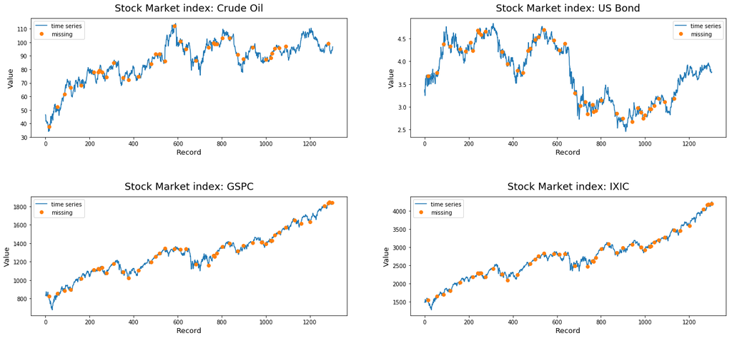

```python
plt.figure(figsize=(20,15))

for miss, fill, indx in zip(list(map(lambda factor: \
                   fillInHistory(
                       trimToRegion( factor, start, end ), \
                       start, end, mode='missing'), \
                   allfactors)), factors, range(1,5)):
    plt.subplot(2,2,indx)
    plt.plot([x[1] for x in fill], label="time series")
    plt.plot([x[1] for x in miss], linestyle='none', marker='o', label="missing")
    plt.title("Stock Market index: {0}".format(MARKET_FACTORS_NAMES[indx-1]), y=1.03, fontsize=18)
    plt.xlabel("Record", fontsize=13)
    plt.ylabel("Value",  fontsize=13)
    plt.legend()

plt.subplots_adjust(left=None, bottom=1.5, right=1, top=2, wspace=None, hspace=0.5)
plt.show()
```

From the plots above we can observe that indeed there are some points in time where we have missing values. We can count how many missing values we have for the four Market Factors.

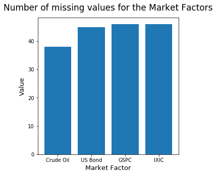

```python
count = list(map(lambda factor: \
                   fillInHistory(
                       trimToRegion( factor, start, end ), \
                       start, end, mode='count'), \
                   allfactors))

plt.figure(figsize=[5, 5])
plt.bar(range(4), count)
plt.title("Number of missing values for the Market Factors", y=1.03, fontsize=17)
plt.xlabel("Market Factor", fontsize=13)
plt.ylabel("Value",  fontsize=13)
plt.xticks(range(4), MARKET_FACTORS_NAMES)
plt.show()
```

We can notice that number of missing values is close for all the four Market factors. With the same process, we investigate now in the stocks. Let's consider the first 29 stocks we have already loaded and see how many values are missing.

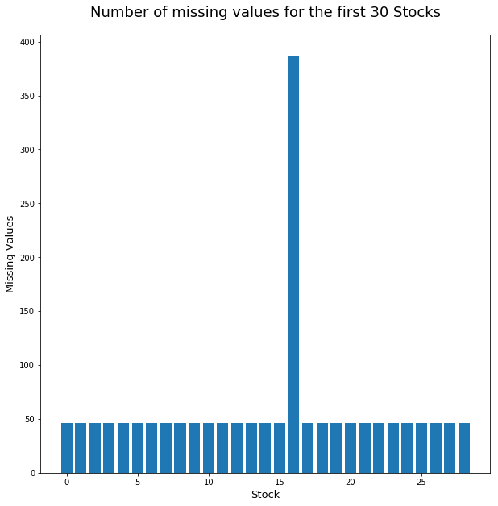

```python
count = list(map(lambda factor: \
                   fillInHistory(
                       trimToRegion( factor, start, end ), \
                       start, end, mode='count'), \
                   rawStocks))

plt.figure(figsize=[10, 10])
plt.bar(range(len(count)), count)
plt.title("Number of missing values for the first 30 Stocks", y=1.03, fontsize=18)
plt.xlabel("Stock", fontsize=13)
plt.ylabel("Missing Values",  fontsize=13)
plt.show()
```

We can notice that the stock in the array with index 16 have a large number of missing values. But what is interesting is that the other stocks are missing all the same values, which is close to the one for the Factors Market. One possible explanation is taht in some day of the week during the year the stock market was closed and so no entries where registered.

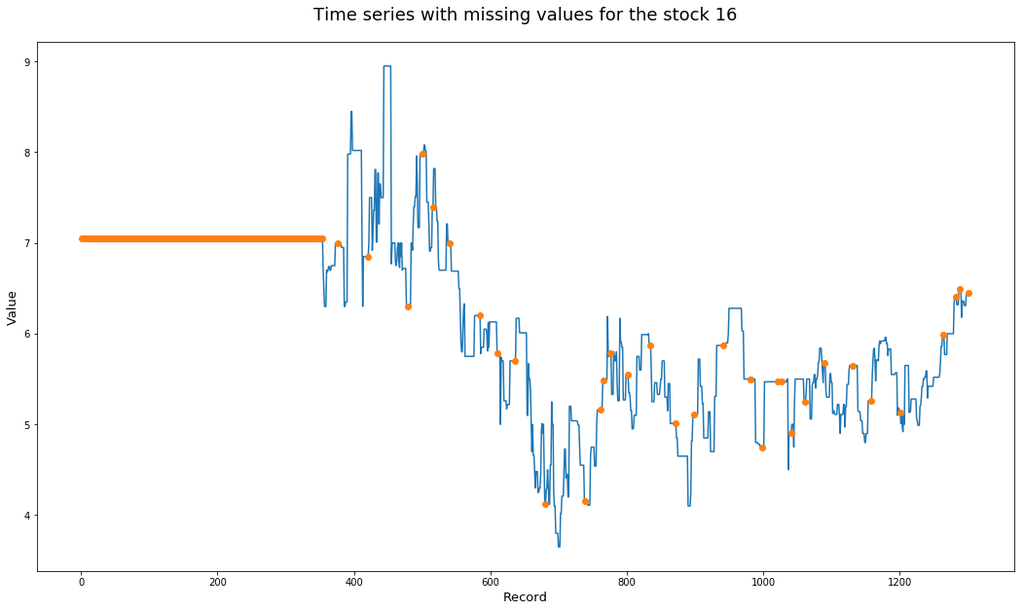

```python
plt.figure(figsize=[18,10])
miss = list(map(lambda factor: fillInHistory( trimToRegion( factor, start, end ), start, end, mode='missing'), rawStocks))
values = stocks[16]

plt.plot([x[1] for x in values], label="time series")
plt.plot([x[1] for x in miss[16]], linestyle='none', marker='o', label="missing")
plt.title("Time series with missing values for the stock 16", y=1.03, fontsize=18)
plt.xlabel("Record", fontsize=13)
plt.ylabel("Value",  fontsize=13)
plt.show()
```

We can see from the plot there is a leading initial missing values for the time searies related to the stock with index 16 in our array.  
We can consider to remove the stock number 16, or in general, define a function whihc takes a treshold and eliminates all the stocks with missing values above that.

```python
def trimAndClean(time_series: list, start: datetime, end: datetime, threshold=75, verbose=False):
    """
    Function used to trim and clean a collection of time series (must be passed as a multidimensional array). The function trim the them
    based on the start and end date, then it replace the missing values. If the number of missing values is above a threshold the
    time serie is then removed from the collection.

    Params:
        time_series: (list) -> a multidimensional array (collection of time series) to be prepared.
        start: (datetime) -> starting period for the time series
        end: (datetime) -> ending period for the time series
        threshold: (int) -> the selected threshold
        verbose: (boolean) -> activate or not the info print
    """

    trimmed = list(map(lambda stock: \
                fillInHistory(
                    # apply the function to each stock to trim it
                    trimToRegion( stock, start, end ), \
                    start, end), \
                      # apply the trim and filling to the stocks selected before
                      time_series))

    count = list(map(lambda stock: \
                fillInHistory(
                    # apply the function to each stock to trim it
                    trimToRegion( stock, start, end ), \
                    start, end, mode='count'), \
                      # apply the trim and filling to the stocks selected before
                      time_series))

    cleaned = [x for x, y in zip(trimmed, count) if y < threshold]

    if verbose:
        print("Cleaned {0!s} stocks due to their number of missing samples > {1!s}".format(len(trimmed)-len(cleaned), threshold))

    return [x for x, y in zip(trimmed, count) if y < threshold]
```

```python
assert(len(trimAndClean(rawStocks, start, end)) < len(rawStocks)), "The function did not removed the stock above the threshold"
```

Recall that Value at Risk (VaR) deals with **losses over a particular time horizon**. We are not concerned with the absolute prices of instruments, but how those prices **change over** a given period of time. In our project, we will set that length to two weeks: we use the sliding window method to transform time series of prices into an overlapping sequence of price change over two-week intervals.

The figure below illustrates this process. The returns of market factors after each two-week interval is calculated in the very same way.

[figure not shown]

```python
def buildWindow(seq, k=2):
    "Returns a sliding window (of width k) over data from iterable data structures"
    "   s -> (s0,s1,...s[k-1]), (s1,s2,...,sk), ...                   "

    # transform the sequence into an iterator
    it = iter(seq)
    # apply the islice method form the itertool class (see note below)
    result = tuple(islice(it, k))
    if len(result) == k:
        # retun the first window of length k
        yield result

    # slice calls the iterator only k times, the remaining elements
    # are those not "sliced" by the funtion
    for elem in it:
        # result is updated each time and we move the window of 1 element
        result = result[1:] + (elem,)
        yield result
```

### From Pyhon Doc:

*itertools.islice(iterable, stop)*  
*itertools.islice(iterable, start, stop[, step])*

Make an iterator that returns selected elements from the iterable. If start is non-zero, then elements from the iterable are skipped until start is reached. Afterward, elements are returned consecutively unless step is set higher than one which results in items being skipped. If stop is None, then iteration continues until the iterator is exhausted, if at all; otherwise, it stops at the specified position. Unlike regular slicing, islice() does not support negative values for start, stop, or step. Can be used to extract related fields from data where the internal structure has been flattened (for example, a multi-line report may list a name field on every third line). Roughly equivalent to:

```
def islice(iterable, *args):
    # islice('ABCDEFG', 2) --> A B
    # islice('ABCDEFG', 2, 4) --> C D
    # islice('ABCDEFG', 2, None) --> C D E F G
    # islice('ABCDEFG', 0, None, 2) --> A C E G
    s = slice(*args)
    start, stop, step = s.start or 0, s.stop or sys.maxsize, s.step or 1
    it = iter(range(start, stop, step))
    try:
        nexti = next(it)
    except StopIteration:
        # Consume *iterable* up to the *start* position.
        for i, element in zip(range(start), iterable):
            pass
        return
    try:
        for i, element in enumerate(iterable):
            if i == nexti:
                yield element
                nexti = next(it)
    except StopIteration:
        # Consume to *stop*.
        for i, element in zip(range(i + 1, stop), iterable):
            pass
```

#### Question 4.6

Compute the returns of the stocks after each two-week time window.

```python
def calculateReturn(window: list):
    """
    Function to compute the Return given a window (values of stocks).
    The return is computed as the difference between the first value and the last one.

    Params:
        window: (list) -> list of values (stocks) from which compute the Return
    """

    # return the change of value after two weeks
    return window[-1][1] - window[0][1]

def twoWeekReturns(history: list):
    """
    Function to compute the Returns in a time window of two weeks for the given hostory of stocks.

    Params:
        history: (list) -> list of values (stocks) from which compute the two week Returns
    """

    # we use 10 instead of 14 to define the window
    # because financial data does not include weekends
    return [calculateReturn(entry) for entry in buildWindow(history, 10)]

stocksReturns = list(map(twoWeekReturns, stocks))
factorsReturns = list(map(twoWeekReturns, factors))

# test our functions
print("The first 5 returns of stock 0:")
pprint(stocksReturns[0][:5])
print("\nThe last 5 returns of stock 0:")
pprint(stocksReturns[0][-5:])
```

```
The first 5 returns of stock 0:
[1.0899999999999999,
 0.8700009999999985,
 0.2999989999999997,
 -2.3100019999999972,
 0.13999899999999954]

The last 5 returns of stock 0:
[-1.3099970000000027,
 -0.6899990000000003,
 -0.7999989999999997,
 0.27999900000000366,
 -0.11999899999999997]
```

Alright! Now we have data that is properly aligned to start the training process: stocks' returns and factors' returns, per time windows of two weeks. Next, we will apply the MCS method.

## 5.5. Summary guidelines to apply the MCS method on the data we prepared

Next, we overview the steps that you have to follow to build a model of your data, and then use Monte Carlo simulations to produce output distributions:

- **Step 1**: Defining the relationship between the market factors and the instrument's returns. This relationship takes the form of a model fitted to historical data.
- **Step 2**: Defining the distributions for the market conditions (particularly, the returns of factors) that are straightforward to sample from. These distributions are fitted to historical data.
- **Step 3**: Generate the data for each trial of a Monte Carlo run: this amount to generating the random values for market conditions along with these distributions.
- **Step 4**: For each trial, from the above values of market conditions, and using the relationship built in step 1, we calculate the return for each instrument and the total return. We use the returns to define an empirical distribution over losses. This means that, if we run 100 trials and want to estimate the 5% VaR, we would choose it as the loss from the trial with the fifth greatest loss.
- **Step 5**: Evaluating the result

## 5.6. Applying MCS

### Step 1: Defining relationship between market factors and instrument's returns

In our simulation, we will use a simple linear model. By our definition of return, a factor return is a **change** in the value of a market factor **over a particular time period**, e.g. if the value of the S&P 500 moves from 2000 to 2100 over a time interval, its return would be 100.

A vector that contains the return of 4 market factors is called a *market factor vector*. Generally, instead of using this vector as features, we derive a set of features from simple transformation of it. In particular, a vector of 4 values is transformed into a vector of length $m$ by function $F$. In the simplest case $F(v) = v$.

Denote $v_t$ the market factor vector, and $f_t$ the transformed features of $v_t$ at time $t$.

$f_{tj}$ is the value of feature $j$ in $f_t$.

Denote $r_{it}$ the return of instrument $i$ at time $t$ and $c_i$ the [intercept term](http://blog.minitab.com/blog/adventures-in-statistics/regression-analysis-how-to-interpret-the-constant-y-intercept) of instrument $i$.

We will use a simple linear function to calculate $r_{it}$ from $f_t$:

$$ r_{it} = c_i + \sum_{j=1}^{m}{w_{ij}*f_{tj}} $$

where $w_{ij}$ is the weight of feature $j$ for instrument $i$.

All that above means that given a market factor vector, we have to apply featurization and then use the result as a surrogate for calculating the return of the instruments, using the above linear function.

There are two questions that we should consider: **how we apply featurization to a factor vector?** and **how to pick values for $w_{ij}$?**

**How we apply featurization to a factor vector?** In fact, the instruments' returns may be non-linear functions of the factor returns. So, we should not use factor returns as features in the above linear function. Instead, we transform them into a set of features with different size. In this Notebook, we can include some additional features in our model that we derive from non-linear transformations of the factor returns. We will try adding two more features for each factor return: its square and its square root values . So, we can still assume that our model is a linear model in the sense that the response variable is a linear function of the new features. *Note that the particular feature transformation described here is meant to be an illustrative example of some of the options that are available: it shouldn't be considered as the state of the art in predictive financial modeling!!*.

**How to pick values for $w_{ij}$?**

For all the market factor vectors in our historical data, we transform them to feature vectors. Now, we have feature vectors in many two-week intervals and the corresponding instrument's returns in these intervals. We can use Ordinary Least Square (OLS) regression model to estimate the weights for each instrument such that our linear function can fit to the data. The parameters for OLS function are:

- `x`: The collection of columns where **each column** is the value of **a feature** in many two-week interval
- `y`: The return of an instrument in the corresponding time interval of x.

The figure below shows the basic idea of the process to build a statistical model for predicting the returns of stock X.

[figure not shown]

### Question 5

#### Question 5.1

Currently, our data is in form of: $$ factorsReturns= \begin{bmatrix} r_{00} & r_{01} & r_{02} & ... & r_{0k} \\ r_{10} & r_{11} & r_{12} & ... & r_{1k} \\ ... & ... & ... & ... & ... \\ r_{n0} & r_{n1} & r_{n2} & ... & r_{nk}\\ \end{bmatrix} $$

$$ stocksReturns= \begin{bmatrix} s_{00} & s_{01} & s_{02} & ... & s_{0k} \\ s_{10} & s_{11} & s_{12} & ... & s_{1k} \\ ... & ... & ... & ... & ... \\ s_{n0} & s_{n1} & s_{n2} & ... & s_{nk}\\ \end{bmatrix} $$

Where, $r_{ij}$ is the return of factor $i^{th}$ in time window $j^{th}$, $k$ is the number of time windows, and $n$ is the number of factors. A similar definition goes for $s_{ij}$.

In order to use OLS, the parameter must be in form of:

$$ x=factorsReturns^T = \begin{bmatrix} r_{00} & r_{10} & ... & r_{n0} \\ r_{01} & r_{11} & ... & r_{n1} \\ r_{02} & r_{12} & ... & r_{n2}\\ ... & ... & ... & ... \\ r_{0k} & r_{1k} & ... & r_{nk}\\ \end{bmatrix} $$

Whereas, $y$ can be any row in `stocksReturns`.

So, we need a function to transpose a matrix. Write a function named `transpose` to do just that.

```python
def transpose(matrix):
    # temporary sotre the transposed matrix. It returns an nparray
    tmp = np.transpose(matrix)
    # return a list instead of an nparray
    return tmp.tolist()

# test function
assert (transpose([[1,2,3], [4,5,6], [7,8,9]]) == [[1, 4, 7], [2, 5, 8], [3, 6, 9]]), "Function transpose runs incorrectly"
```

#### Question 5.2

Write a function named `featurize` that takes a list factor's returns $[x_1, x_2,...,x_k]$ and transform it into a new list of features $[u_1,u_2,..,u_k, v_1, v_2,..,v_k, x_1,x_2,...,x_k]$.

Where, $u_i$ = $\left\{ \begin{array}{ll} x_i^2 & \mbox{if } x_i \geq 0 \\ -x_i^2 & \mbox{if } x_i < 0 \end{array} \right. $

and $v_i$ = $\left\{ \begin{array}{ll} \sqrt{x_i} & \mbox{if } x_i \geq 0 \\ -\sqrt{x_i} & \mbox{if } x_i < 0 \end{array} \right. $

```python
from math import sqrt, pow

def featurize(factorReturns):
    """
    Function to featurize a vector of factors adding two additional features for each factor: the sqrt and the square of the original factor
    keeping the sign. The returned value is a vector with the original features and the added ones.

    Params:
        factorReturns: (list) -> vecotr of original factors to be featurized
    """

    squaredReturns = [pow(x, 2) if x >= 0 else -1 * pow(x, 2) for x in factorReturns]
    squareRootedReturns = [sqrt(x) if x >= 0 else -1 * sqrt(abs(x)) for x in factorReturns]
    # concat new features
    return  squaredReturns + squareRootedReturns + factorReturns
```

```python
# test our function
assert (featurize([4, -9, 25]) == [16, -81, 625, 2, -3, 5, 4, -9, 25]), "Function runs incorrectly"
```

#### Question 5.3

Using OLS, estimate the weights for each feature on each stock. What is the shape of `weights` (size of each dimension)? Explain it.

```python
def estimateParams(y, x):
    return sm.OLS(y, x).fit().params

# transpose factorsReturns (so that: rows = time windows, cols = factors)
factorMat = transpose(factorsReturns)

# featurize each row of factorMat (square - squaredRoot - return)
factorFeatures = list(map( featurize, factorMat))

# OLS requires parameter as a numpy array
factor_columns = np.array(factorFeatures)

#add a constant - the intercept term for each instrument i.
factor_columns = sm.add_constant(factor_columns, prepend=True)

# estimate weights
weights = [ estimateParams( stocksReturn, factor_columns ) for stocksReturn in stocksReturns ]

print("Weights:")
pprint(weights[:5])
```

```
Weights:
[array([ 9.39611484e-03, -2.24923981e-03, -5.99205725e+00,  2.10527661e-04,
       -4.34683201e-05,  4.13999684e-02, -6.43645957e-01,  2.68682255e-02,
       -6.24574664e-02, -4.89192009e-03,  3.00598718e+00,  2.72813269e-03,
        1.10293691e-02]),
 array([-1.02641706e-01,  2.88864804e-03, -1.41925540e+00,  2.75230634e-04,
       -5.41705207e-05,  2.14642786e-01,  5.26108473e-01,  9.71236720e-02,
       -4.08289974e-02, -1.14020390e-01,  6.57880469e-01, -3.53061509e-02,
        3.07777547e-02]),
 array([-1.43969807e-02,  2.49490009e-03, -1.62419755e+00,  5.48437048e-05,
       -1.28938924e-05,  4.00004025e-02, -1.14878328e-01,  9.05861023e-04,
       -1.96411912e-03, -4.90643513e-02,  7.05954176e-01, -1.31749437e-03,
        2.51283763e-03]),
 array([ 4.79588741e-02, -7.06353949e-04,  6.14416201e+00, -1.34419767e-05,
       -4.85588849e-06,  6.86322712e-03,  2.30517952e+00,  4.94052601e-02,
       -6.21667222e-02,  6.67029834e-03, -6.94893110e+00, -5.02756759e-03,
        9.86800596e-03]),
 array([-2.02174375e-01,  8.40826799e-03,  3.19007816e+00,  3.86206818e-04,
       -6.94458607e-05,  2.13916127e-02,  3.30991566e-01,  2.69027928e-01,
       -7.28808223e-02, -9.98221978e-02,  7.66077943e-01, -6.49443081e-02,
        2.59590610e-02])]
```

```python
print("Cofficents' dimensionality: {0!s}".format(len(weights[0])))
print("Weight vector's dimensionality: {0!s}".format(len(weights)))
```

```
Cofficents' dimensionality: 13
Weight vector's dimensionality: 29
```

### Step 2: Defining the distributions for the market conditions

Since we cannot define the distributions for the market factors directly, we can only approximate their distribution. The best way to do that, is plotting their value. However, these values may fluctuate quite a lot.

Next, we show how to use the Kernel density estimation (KDE) technique to approximate such distributions. In brief, kernel density estimation is a way of smoothing out a histogram: this is achieved by assigning (or centering) a probability distribution (usually a normal distribution) to each data point, and then summing. So, a set of two-week-return samples would result in a large number of "super-imposed" normal distributions, each with a different mean.

To estimate the probability density at a given point, KDE evaluates the PDFs of all the normal distributions at that point and takes their average. The smoothness of a kernel density plot depends on its *bandwidth*, and the standard deviation of each of the normal distributions. For a brief introduction on KDE, please refer to this [link](https://en.wikipedia.org/wiki/Kernel_density_estimation).

```python
from statsmodels.nonparametric.kernel_density import KDEMultivariate
from statsmodels.nonparametric.kde import KDEUnivariate
from scipy.stats import norm

def computeKerneDensity(samples: list):
    """
    Function to compute the Kernel Density for a passed vector of samples. It returns the computed density
    and the domain to plot the results.

    Params:
        sampels: (list) -> array of samples from which compute the KD
    """

    vmin = min(samples)
    vmax = max(samples)
    stddev = np.std(samples)
    domain = np.arange(vmin, vmax, (vmax-vmin)/100)

    # a simple heuristic to select bandwidth: Silverman's rule of thumb
    bandwidth = 1.06 * stddev * pow(len(samples), -.2)

    # estimate density using Univariate (FFT faster)
    kde = KDEUnivariate(samples)
    kde.fit(bw=bandwidth)
    density = kde.evaluate(domain)

    return domain, density
```

```python
def plotDistribution(samples, indx=None):
    domain, density = computeKerneDensity(samples)
    mean = np.mean(samples)
    stddev = np.std(samples)

    # plot
    plt.subplot(2,2,indx+1)
    plt.plot(domain, density)
    # plot the comparison with the normal distribution
    plt.plot(domain, norm.pdf(domain, mean, stddev), '--')
    plt.title("PDF using KDE - {0}".format(MARKET_FACTORS_NAMES[indx]), y=1.05, fontsize=16)
    plt.xlabel("Values")
    plt.ylabel("Probability")

    plt.subplots_adjust(left=None, bottom=1.5, right=1, top=2, wspace=None, hspace=0.5)
```

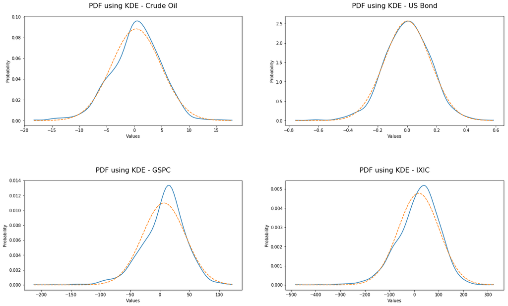

```python
plt.figure(figsize=[18,18])
for indx in range(4):
    plotDistribution(factorsReturns[indx], indx)
plt.show()
```

For more details about the KDEUnivariate method: [link](https://www.statsmodels.org/stable/generated/statsmodels.nonparametric.kde.KDEUnivariate.fit.html#statsmodels.nonparametric.kde.KDEUnivariate.fit)

For the sake of simplicity, we can say that our smoothed versions of the returns of each factor can be represented quite well by a normal distribution. Of course, more exotic distributions, perhaps with fatter tails, could fit more closely the data, but it is outside the scope of this Notebook to proceed in this way.

Now, the simplest way to sample factors returns is to use a normal distribution for each of the factors, and sample from these distributions independently. However, this approach ignores the fact that market factors are often correlated. For example, when the price of crude oil is down, the price of treasury bonds is down too. We can check our data to verify about the correlation.

### Question 6

#### Question 6.1

Calculate the correlation between market factors and explain the result.

HINT

function `np.corrcoef` might be useful.

### From Numpy Doc:

*corrcoef(x, y=None, rowvar=True, bias=np._NoValue, ddof=np._NoValue)*

- x : array_like -> A 1-D or 2-D array containing multiple variables and observations. Each row of x represents a variable, and each column a single observation of all those variables. Also see rowvar below.

```python
# we pass the factorsReturns matrix to compute the correlation
correlation = np.corrcoef(factorsReturns)
correlation
```

```
array([[1.        , 0.38507954, 0.47411609, 0.45841194],
       [0.38507954, 1.        , 0.55213086, 0.54918324],
       [0.47411609, 0.55213086, 1.        , 0.95227596],
       [0.45841194, 0.54918324, 0.95227596, 1.        ]])
```

```python
import pandas as pd
df2 = pd.DataFrame({ "Crude Oil":correlation[0], "US Bond":correlation[1], "GSPC": correlation[2], "IXIC": correlation[3]})
df2 = df2[MARKET_FACTORS_NAMES]
```

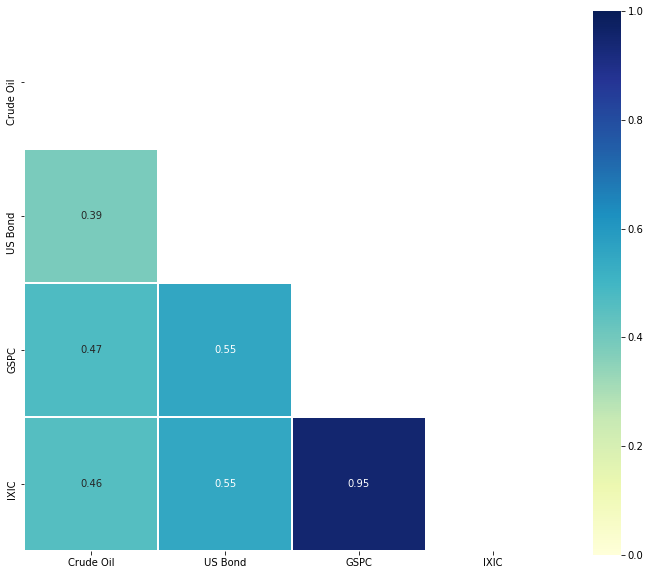

```python
from seaborn import heatmap, axes_style

mask = np.zeros_like(correlation)
mask[np.triu_indices_from(mask)] = True

plt.figure(figsize=[12,10])
heatmap(df2, mask=mask, vmin=0.0, vmax=1, square=True, linewidths=.5, annot=True, cmap="YlGnBu", yticklabels=MARKET_FACTORS_NAMES)
```

## Comment

The resulting correlation coefficients are a 4 by 4 matrix, which is complient to the fact that we are dealing with only four *Factors*. The diagonal is the autocorrelation, thus is set to 1. The other entries represent the cross-correlation between two different factors. We can notice indeed that the matrix is simmetric.  
About the values, the magnitude of each coefficent is an index of how strong the relation between the two factors is. Indeed, the more a magnitude value is closed to 1 the more the second factor changes when the first one does. This changes have the same sign if the correlation is positive, different sign otherwise. Vice-versa, if the value tends to be zero, there is lower if not significant variation of a factor in relation to the other one.  
In order to better understand the domain, we have to look on the Internet what those Market Factors represent. We have found the following information:

- **Crude Oil**: it's the price of the crude oil. This is a commodity, which variation in the price may contribute significantly on the price variation of other goods. Indeed, we expect this to be correlated mainly to those stocks which represents marketing of goods which requires shipments or have a direct relation (for example the crude oil or derivatives are used to produce the good) with the crude oil.
- **US Bonds**: it's the rate of interest for government bonds. An U.S. saving bond is a bond issued by the governmental body which acts like a loan taken from the public to fund operations and capital projects. The bonds represent a safe investment and if the demand is high the interest is reduced, on the countrary it is risen: when the interest rate is high, it usually means that the economy is healthy (people prefer to invest in stocks rather than in bonds).  
  During periods of economic expansion, bonds and the stock market trade inversely as they are competing for capital. Finally, as written in [investopedia](https://www.investopedia.com/ask/answers/061715/how-can-bond-yield-influence-stock-market.asp), during economic recoveries bonds and stocks move together.
- **GSPC**: Also named S&P 500 Index. It's the Standard & Poors index which is based on 500 companies' market capitlization [companies list](https://en.wikipedia.org/wiki/List_of_S%26P_500_companies) with common stocks listed in NYSE or NASDAQ. It's a good representation of the U.S. stock Market.
- **IXIC**: It's a stock market index called NASDAQ Composite of the common stocks (a form of corporate ownership and type of security also known as Equity Share) and securities. Together with the S&P500 and the Down Jones Average, it represents one of the main followed indices in the U.S. stock market. Also, the major composition of stocks for this index is biased towards information technology companies.

Once we have acquired information about the Market Factors, we can reason about the high correlation between the **GSPC** and **IXIC** indeces. The reason it's mostly due to the fact that this two indices represent two major U.S. stock market indeces, allong with the **Dow Jones**, so they are some how similar in their trend.  
But what is of interest is that the **US Bonds** are somehow correlated with the **GSPC** and **IXIC** indeces. We can explain it a bit. We are considering data from 2009 to 2014: recalling what it has been explained above for the **US Bonds** and their relation with the stocks' values, between the 2007 and 2008 a financial crisis took place worldwide starting from the US with the *subprime mortgage market* [link](https://en.wikipedia.org/wiki/Financial_crisis_of_2007–2008). The aftermath of this would have implied an economy recovery which may be the reason of such correlation between the factors mentioned above.  
We can now decide to create a portfolio which includes the stocks directly involved in the computation of the GSPC and IXIC indexes (or more related to them: for example the technology companies, because of the IXIC nature).

The multivariate normal distribution can help here by taking the correlation information between the factors into account. Each sample from a multivariate normal distribution can be thought of as a vector. Given values for all of the dimensions but one, the distribution of values along that dimension is normal. But, in their joint distribution, the variables are not independent.

For this use case, we can write:

$$ \left(\begin{array}{c}f_{1}\\f_{2}\\f_{3}\\f_{4} \end{array}\right) \sim N \left[ \left( \begin{array}{c} \mu_1\\ \mu_2 \\ \mu_3 \\ \mu_4 \end{array} \right), \left( \begin{array}{cccc} \sigma^2_1 & \rho_{12} \sigma_1\sigma_2 & \rho_{13} \sigma_1\sigma_3 & \rho_{14} \sigma_1\sigma_4 \\ \rho_{12}\sigma_2\sigma_1 & \sigma^2_2 & \rho_{23} \sigma_2\sigma_3 & \rho_{24} \sigma_2\sigma_4\\ \rho_{13} \sigma_3\sigma_1 & \rho_{23} \sigma_3\sigma_2 & \sigma^2_3 & \rho_{34} \sigma_3\sigma_4 \\ \rho_{14} \sigma_4\sigma_1 & \rho_{24} \sigma_4\sigma_2 & \rho_{34} \sigma_3\sigma_4 & \sigma_4^2 \\ \end{array} \right) \right] $$

Or,

$$ f_t \sim N(\mu, \sum) $$

Where $f_1$, $f_2$, $f_3$ and $f_4$ are the market factors, $\sigma_i$ is the standard deviation of factor $i$, $\mu$ is a vector of the empirical means of the returns of the factors and $\sum$ is the empirical covariance matrix of the returns of the factors.

The multivariate normal is parameterized with a mean along each dimension and a matrix describing the covariance between each pair of dimensions. When the covariance matrix is diagonal, the multivariate normal reduces to sampling along each dimension independently, but placing non-zero values in the off-diagonals helps capture the relationships between variables. Whenever having the mean of this multivariate normal distribution and its covariance matrix, we can generate the sample values for market factors.

Next, we will calculate the mean and the covariance matrix of this multivariate normal distribution from the historical data.

#### Question 6.2

Calculate the covariance matrix $\sum$ and the means $\mu$ of factors' returns then generate a random vector of factors return that follows a multivariate normal distribution $\sim N(\mu, \sum)$

HINT

Function `np.cov` can help calculating covariance matrix. Function `np.random.multivariate_normal(<mean>, <cov>)` is often used for generating samples.

```python
factorCov = np.cov(factorsReturns)
factorMeans = [ sum(factorsReturn)/len(factorsReturn) for factorsReturn in factorsReturns ]
sample = np.random.multivariate_normal(factorMeans, factorCov)
print("Covariance:")
pprint(factorCov)
print("\nMeans:")
pprint(factorMeans)
print("\nSample:")
pprint(sample)
```

```
Covariance:
array([[2.03712313e+01, 2.70383097e-01, 7.77281497e+01, 1.72733934e+02],
       [2.70383097e-01, 2.42014227e-02, 3.11994882e+00, 7.13264857e+00],
       [7.77281497e+01, 3.11994882e+00, 1.31938031e+03, 2.88775882e+03],
       [1.72733934e+02, 7.13264857e+00, 2.88775882e+03, 6.96989443e+03]])

Means:
[0.35908880308880364,
 0.0019722007722007863,
 6.953868592277998,
 18.7092272903475]

Sample:
array([ 1.73505313, -0.21559401,  6.51429876,  9.88048642])
```

### Step 3&4: Generating samples, running simulation and calculating the VaR

We define some functions that helps us calculating VaR 5%. You will see that the functions below are pretty complicated! This is why we provide a solution for you: however, study them well!!

The basic idea of calculating VaR 5% is that we need to find a value such that only 5% of the losses are bigger than it. That means the 5th percentile of the losses should be VaR 5%.

VaR can sometimes be problematic though, since it does give any information on the extent of the losses which can exceed the VaR estimate. CVar is an extension of VaR that is introduced to deal with this problem. Indeed, CVaR measures the expected value of the loss in those cases where VaR estimate has been exceeded.

```python
# it returns the top 5% losses given from the trial
def fivePercentVaR(trials):
    numTrials = trials.count()
    # return the first 5% smallest values. Note this is why numTrials is divided by 20!
    topLosses = trials.takeOrdered(max(round(numTrials/20.0), 1))
    # take the last of the list, which is also the best trial
    return topLosses[-1]

# an extension of VaR, it returns the average of the topLosses
def fivePercentCVaR(trials):
    numTrials = trials.count()
    topLosses = trials.takeOrdered(max(round(numTrials/20.0), 1))
    return sum(topLosses)/len(topLosses)

# used to get a confidence interval on the VAR statistic
# achieved sampling with replacement from the set of portfolio returns (result of trials)
def bootstrappedConfidenceInterval(trials, computeStatisticFunction, numResamples, pValue):
    stats = []
    for i in range(0, numResamples):
        # sample with replacement from the set of returns
        resample = trials.sample(True, 1.0)
        # use the passed function, selected amongst the two defined above
        stats.append(computeStatisticFunction(resample))
    sorted(stats)
    lowerIndex = int(numResamples * pValue / 2 - 1)
    upperIndex = int(np.ceil(numResamples * (1 - pValue / 2)))
    return (stats[lowerIndex], stats[upperIndex])
```

Next, we will run the Monte Carlo simulation 10,000 times, in parallel using Spark. Since your cluster has 12 cores (two Spark worker nodes, each with 6 cores), we can set `parallelism = 12` to dispatch simulation on these cores, across the two machines (remember, those are not really "physical machines", they are Docker containers running in our infrastructure).

### Question 7

Complete the code below to define the simulation process and calculate VaR 5%.

```python
def simulateTrialReturns(num_trials: int, weights: list, dist_sampl_f: object, dist_sampl_p: list, featurize_f: object):
    """
    Function to compute the simulated returns of a portfolio. It is adopted in a MCS exploiting a distributed
    implementation. During each trial, the factorReturns for the market are drowned from a Multivariate Student's t
    distribution. Different trials are run in a single taks. The function is generalized in order to receive functions to
    compute the features and the samples for a selected distribution.

    Params:
        numTrials: (int) -> the number of trials in a single task
        weights: (list) -> the matrix of weights precomputed for the linear model
        dist_sampl_f: (object) -> the function from which generate the trialFactorReturns
        dist_sampl_p: (list) -> the parameters for the passed dist_sampl_f function
        featurize_f: (object) -> the funtion to apply to featurize
    """

    trial_returns = []
    np_weights = np.array(weights)

    # a bunch of trials is performed for each task
    for i in range(0, num_trials):
        # generate sample of factors' returns
        #trialFactorReturns = np.random.multivariate_normal(factorMeans, factorCov)
        trial_factor_returns = dist_sampl_f(*dist_sampl_p)

        # featurize the factors' returns
        #trialFeatures = featurize(trialFactorReturns.tolist())
        trial_features = featurize_f(trial_factor_returns.tolist())

        # insert weight for intercept term, this comes in hand when performing the inner product
        # due to the length of the vector becomes 13
        trial_features.insert(0,1)

        # the return for the single instrument is computed performing the inner product of the matrix
        # of weights (derived from instruments) and the array of generated 'trial features'.
        trial_total_return = sum(np_weights.dot(np.array(trial_features)))/len(np_weights)

        trial_returns.append(trial_total_return)

    return trial_returns
```

### Implementation Comments

Some notes based on what we have seen in the book *Advanced Analytics with Spark* chapter 9.  
First we exploited the numpy library to perform the computation of the single returns $r_{it}$ for each instrumenr $i$ as an inner product. This was possible transforming the vector of *trialFeatures* adding 1 as leading value (the value which multiply the intercept). The result of the inner product between the matrix of derived weights for the instruments (passed as *weights*) and the *trialFeatures* produces a vector of Returns.  
In addition, we have average over all the returns for all instruments to compute the totalReturn, under assumption that we are holding an equal value of each instrument in the portfolio. Under this implementation, we are considering the average loss of the portfolio. The consequence of this is reflected on the VaR and CVaR which represents then the average risk for each stock instead of the total risk of the portfolio.

```python
# proof of dimensionality
trialFactorReturns = np.random.multivariate_normal(factorMeans, factorCov)
trialFeatures = featurize(trialFactorReturns.tolist())
trialFeatures.insert(0,1)

print("The trailFeatures vector has shape: {!s}".format(np.array(trialFeatures).shape))
print("The weights vecotr has shape {!s}".format(np.array(weights).shape))
```

```
The trailFeatures vector has shape: (13,)
The weights vecotr has shape (29, 13)
```

```python
# RUN SIMULATION
parallelism = 12
numTrials = 10000
trial_indexes = list(range(0, parallelism))
seedRDD = sc.parallelize(trial_indexes, parallelism)
bFactorWeights = sc.broadcast(weights)

trials = seedRDD.flatMap(lambda idx: \
                simulateTrialReturns(
                    max(int(numTrials/parallelism), 1),     # number of trials per task
                    bFactorWeights.value,                   # weights associated with the instruments
                    np.random.multivariate_normal,          # function to generate the samples
                    [factorMeans, factorCov],               # additional parameters for the function distribution (previously computed)
                    featurize                               # function to apply to the maketFactor
                ))
trials.cache()
```

```
PythonRDD[1] at RDD at PythonRDD.scala:48
```

```python
valueAtRisk = fivePercentVaR(trials)
conditionalValueAtRisk = fivePercentCVaR(trials)

print("Value at Risk(VaR) 5%:", valueAtRisk)
print("Conditional Value at Risk(CVaR) 5%:", conditionalValueAtRisk)
```

```
Value at Risk(VaR) 5%: -0.7097311255480075
Conditional Value at Risk(CVaR) 5%: -0.9171863207738558
```

The value of VaR depends on how many invested stocks and the chosen distribution of random variables. Assume that we get VaR 5% = -2.66, that means that there is a 0.05 probability that the portfolio will fall in value by more than \$2.66 over a two weeks' period if there is no trading. In other words, the loses are less than \$2.66 over two weeks' period with 95% confidence level. When a loss over two weeks is more than \$2.66, we call it **failure** (or **exception**). Informally, because of 5% probability, we expect that there are only $0.05*W$ failures out of total $W$ windows.

### Step 5: Evaluating the results using backtesting method

In general, the error in a Monte Carlo simulation should be proportional to 1/sqrt(n), where n is the number of trials. This means, for example, that quadrupling the number of trials should approximately cut the error in half. A good way to check the quality of a result is backtesting on historical data. Backtesting is a statistical procedure where actual losses are compared to the estimated VaR. For instance, if the confidence level used to calculate VaR is 95% (or VaR 5%), we expect only 5 failures over 100 two-week time windows.

The most common test of a VaR model is counting the number of VaR failures, i.e., in how many windows, the losses exceed VaR estimate. If the number of exceptions is less than selected confidence level would indicate, the VaR model overestimates the risk. On the contrary, if there are too many exceptions, the risk is underestimated. However, it's very hard to observe the amount of failures suggested by the confidence level exactly. Therefore, people try to study whether the number of failures is reasonable or not, or will the model be accepted or rejected.

One common test is Kupiec's proportion-of-failures (POF) test. This test considers how the portfolio performed at many historical time intervals and counts the number of times that the losses exceeded the VaR. The null hypothesis is that the VaR is reasonable, and a sufficiently extreme test statistic means that the VaR estimate does not accurately describe the data. The test statistic is computed as:

$$ -2ln\Bigg(\frac{(1-p)^{T-x}p^x}{(1-\frac{x}{T})^{T-x}(\frac{x}{T})^x}\Bigg) $$

where:

$p$ is the quantile-of-loss of the VaR calculation (e.g., in VaR 5%, p=0.05),

$x$ (the number of failures) is the number of historical intervals over which the losses exceeded the VaR

$T$ is the total number of historical intervals considered

Or we can expand out the log for better numerical stability:

$$ \begin{equation} -2\Big((T-x)ln(1-p)+x*ln(p)-(T-x)ln(1-\frac{x}{T})-x*ln(\frac{x}{T})\Big) \end{equation} $$

If we assume the null hypothesis that the VaR is reasonable, then this test statistic is drawn from a chi-squared distribution with a single degree of freedom. By using Chi-squared distribution, we can find the `p-value` accompanying our test statistic value. If `p-value` exceeds the critical value of the Chi-squared distribution, we do have sufficient evidence to reject the null hypothesis that the model is reasonable. Or we can say, in that case, the model is considered as inaccurate.

### Question 8

#### Question 8.1

Write a function to calculate the number of failures, that is when the losses (in the original data) exceed the VaR.

HINT

- First, we need to calculate the total loss in each 2-week time interval
- If the total loss of a time interval exceeds VaR, then we say that our VaR fails to estimate the risk in that time interval
- Return the number of failures

NOTE

The loss is often having negative value, so, be careful when compare it to VaR.

```python
from scipy import stats
import math

def countFailures(stocksReturns, valueAtRisk):
    failures = 0
    # iterate over time intervals
    for i in range(0, len(stocksReturns[0])):
        # calculate the losses in each time interval
        # retrieve the column of the stocksReturns matrix
        # corresponding to a given time interval
        loss = sum(map(lambda x: x[i], stocksReturns))/len(stocksReturns)

        # if the loss exceeds VaR
        if loss < valueAtRisk:
            failures += 1
    return failures
```

#### Question 8.2

Write a function named `kupiecTestStatistic` to calculate the test statistic which was described in the above equation.

```python
def kupiecTestStatistic(total, failures, confidenceLevel):
    failureRatio = failures /total
    # use the np.log1p form the numpy library to compute the natural logarithm of one plus the input array, element-wise
    logNumer = (total - failures) * np.log1p(-confidenceLevel) + failures * np.log(confidenceLevel)
    logDenom = (total - failures) * np.log1p(-failureRatio) + failures * np.log(failureRatio)
    return -2 * (logNumer - logDenom)

# test the function
assert (round(kupiecTestStatistic(250, 36, 0.1), 2) == 4.80), "function kupiecTestStatistic runs incorrectly"
```

Now we can find the p-value accompanying our test statistic value.

```python
def kupiecTestPValue(stocksReturns: list, valueAtRisk: float, confidenceLevel: float):
    """
    Function to compute the  Kupiec's proportion-of-failures (POF) test. It returns the test p-value and the number of failures.

    Params:
        stocksReturns: (list) -> the list of Stock Returns
        valueAtRisk: (float) -> the preconputed value at risk (VaR)
        confidenceLevel: (float) -> the requested confidence level
    """

    failures = countFailures(stocksReturns, valueAtRisk)
    N = len(stocksReturns)
    #print("num failures:", failures)
    total = len(stocksReturns[0])
    testStatistic = kupiecTestStatistic(total, failures, confidenceLevel)
    #return 1 - stats.chi2.cdf(testStatistic, 1.0)
    return stats.chi2.sf(testStatistic, 1.0), failures
```

```python
varConfidenceInterval = bootstrappedConfidenceInterval(trials, fivePercentVaR, 100, .05)
cvarConfidenceInterval = bootstrappedConfidenceInterval(trials, fivePercentCVaR, 100, .05)
print("VaR confidence interval: {0!s}".format(varConfidenceInterval))
print("CVaR confidence interval: {0!s}".format(cvarConfidenceInterval))
print("Kupiec test p-value: {0!s}  -- number of failures: {1!s} ".format(*kupiecTestPValue(stocksReturns, valueAtRisk, 0.05)))
```

```
VaR confidence interval: (-0.6922939335903164, -0.726868574375949)
CVaR confidence interval: (-0.89479959444081, -0.9042578586745074)
Kupiec test p-value: 7.590669407277123e-07  -- number of failures: 107
```

#### Question 8.3

Discuss the results you have obtained

### Comments

The *p-value* is very low (order $10^{-7}$): this means that we have enough evidence to reject the null hypothesis $H_{0}$ (in other words: the VaR is not reasonable). If we would have looked only at the confidence interval, maybe the model results could have been considered interesting enough to make us invest money: but the backtesting method showed that, actually, when the model is tested over real data it does not perform as well as espected.  
That is, it fails the chi-squared test: we should look for a method to increase the quality of the model, maybe trying different distributions to generate the samples.

### Question 9

Assume that we invest in more than 100 stocks. Use the same market factors as for the previous questions to estimate VaR by running MCS, then validate your result. What is the main observation you have, once you answer this question? When you plan to invest in more instruments, how is your ability to predict the risk going to be affected?

### Toolset

Here there is a collection of functions which are defined for further simulations.

```
def prepareRawStocks(stock_folder: str, number_stocks: int, indx_start=0, number_years=5):
    """
    Function to load and prepare the stocks for the portfolio.
    The stocks are saved in saparate files and it's possible to specify the number of stocks to load.
    Additionaly, it's possible to cut the stocks for which there are less than 'numb_years', assuming 260 working days.

    Params:
        stock_folder: (str) -> the path from which retrieve the files
        number_stocks: (int) -> specify the number of different stocks to load
        indx_start: (int) -> specify the starting range from which select stocks to load
        number_years: (int) -> define the number of years minimum for the stocks entries
    """

    # load the files sotcks names
    files = [join(stock_folder, f) for f in listdir(stock_folder) if isfile(join(stock_folder, f))]
    assert( len(files) > number_stocks), " There are no enough stock data, try a different number lower or equal {0!s}".format(len(files))

    # consider only the invested quantity
    files = files[indx_start:number_stocks]

    # read each line in each file, convert it into the format: (date, value)
    rawStocks = [processStockFile(f) for f in files]

    # assumption of one record per day
    rawStocks = list(filter(lambda instrument: len(instrument) > number_of_years * 260, rawStocks))

    return rawStocks
```

```
def prepareStocks(stock_folder: str, number_stocks: int, start: datetime, end: datetime, thr=60, verbose=False):
    """
    Function used to prepare the right number of stocks and trim to the wanted window of time.
    The function tries to return a number of different stocks close to the wanted value.

    Params:
        stock_folder: (str) -> the path from which retrieve the files
        number_stocks: (int) -> specify the number of different stocks to load
        start: (datetime) -> starting period for the time series of the stocks
        end: (datetime) -> ending period for the time series of the stocks
        thr: (int) -> the threshold to remove time series with too many missing values
        vebose: (boolean) -> decide if activate or not the print of the status
    """

    # try with the initial number of wanted stocks, if not increas untill the wanted number is reached
    raw_stocks = []
    prev_indx_start = 0
    try_num_stocks = number_stocks
    if verbose:
        print("Searching for the wanted number of stocks!")

    while (len(raw_stocks) < number_stocks):
        # prepare the stocks and add to the pool
        raw_stocks += prepareRawStocks(stock_folder, try_num_stocks, prev_indx_start)
        # incremenet the number of stocks to pull
        prev_indx_start = try_num_stocks
        try_num_stocks += 10

    # note that the data of crude oil and treasury is only available starting from 26/01/2006
    # we use the trimAndClean function to remove eventual stocks which presents too many missing values
    stocks = trimAndClean(raw_stocks, start, end, threshold=thr, verbose=verbose)

    if verbose:
        print("Total number of stocks prepared: {0!s}".format(len(stocks)))

    return stocks
```

```
def computeWeights(stocks_r: list, factors_r: list, featurize_f: object, estimate_f: object):
    """
    Function to compute the weights for the linear model of the returns.
    It is possible to pass the function to use for computing the linar model.

    Params:
        stocks_r: (list) -> the list of Stocks Returns
        factors_r: (list) -> the list of Factor Returns
        featurize_f: (object) -> the function to apply for the featurization
        estimate_f: (object) -> the function to apply for the linear model
    """

    # transpose factorsReturns
    factor_mat = transpose(factors_r)

    # featurize each row of factorMat
    factor_features = list(map( featurize_f, factor_mat))

    # OLS require parameter is a numpy array
    factor_columns = np.array(factor_features)
    #add a constant - the intercept term for each instrument i.
    factor_columns = sm.add_constant(factor_columns, prepend=True)

    # estimate weights
    weights = [ estimate_f( s, factor_columns ) for s in stocks_r ]

    return weights
```

```
def runGeneralMCS(weights: list, simulate_trial_returns_p: list, simulate_trial_returns_f=simulateTrialReturns, parallelism=12, numb_trials=10000):
    """
    Function to run the simulation in a distribute fashion. The idea is to broadcast the weights matrix (which can be stored in the main memory: in fact, even
    with 1M instruments and 500 factors its memory size would be roughly 4GB). Then, use the cluster to simulate many runs in parallel.

    Params:
        weights: (list) -> the weight matrix to be broadcasted
        simulate_trial_returns_p: (list) -> additional parameters for the passed simulate_trial_returns_f function
        simulate_trial_returns_f: (object) -> pass the function to apply for simulating the market conditions
        parallelism: (int) -> indicate the paralellism number
        numb_trials: (int) -> number of trials
    """

    # define seeds to properly
    seedRDD = sc.parallelize(list(range(0, parallelism)), parallelism)
    b_factor_weights = sc.broadcast(weights)

    trials = seedRDD.flatMap(lambda idx: \
                    simulate_trial_returns_f(
                        # number of trials per task
                        max(int(numTrials/parallelism), 1),
                        # weights associated with the instruments
                        b_factor_weights.value,
                        # expand the vector of parameters
                        *simulate_trial_returns_p
                    ))
    trials.cache()
    return trials
```

```
def runCompleteExperimentGeneral(numb_stocks:int, start: datetime, end:datetime, regression_f:object, sample_dist_funct:object,
                                 sample_dist_params: list, results: dict, numb_trials:int, parallelims=12, threshold=60,
                                 featurize=featurize, load_stocks=True, verbose=True, prep_stock_verbose=True):
    """
    Function to compute the whole simulation. This is divided in 5 steps:
        (1) RELATIONSHIP WITH MARKET FACTORS
        (2) DEFINING THE DISTRIBUTION
        (3 & 4) GENERATE SAMPLES AND CALCULATE VaR
        (5) RESULT EVALUATION
    The function accept a set of parameter which are used to configure the simulation.

    Params:
        numb_stocks: (int) -> number of stocks to load from the available file
        start: (datetime) -> starting period to consider for the time series
        end: (datetime) -> ending period to consider for the time series
        regression_f: (object) -> regression function to apply for the weigth estimation
        sample_dist_funct: (object) -> function used to produce the sampled (a distribution)
        sample_dist_params: (list) -> paramters of the function passed for the samples
        results: (dict) -> to save the results of the simulation (see notes)
        numb_trials: (int) -> number of trials for the MCS
        parallelims: (int) -> parallelism for the distributed computation
        threshold: (int) -> threshold for cleaning the stocks which present too many missing values
        featurize: (object) -> function to compute the feature for the regression model
        load_stocks: (boolean) -> to save computational time, if the stocks are already loaded
        verbose: (boolean) -> decide if print or not the status of the execution
        prep_stock_verbose: (boolean) -> decide if print or not the status for the cleaning function

    Notes:
        The dictionary to be passed for saving the results (mandatory):
        results = {
            "num_stocks": [],
            "value_at_risk": [],
            "conditional_value_at_risk": [],
            "var_confidence_interval": [],
            "cvar_onfidence_interval": [],
            "p_value": [],
            "failures": []
          }
    """

    if verbose:
        print("Starting MCS!")

    global stocks_returns
    global factors_returns

    if load_stocks:
        ## (1) RELATIONSHIP WITH MARKET FACTORS ##
        # prapre the stocks
        stocks = prepareStocks(stock_folder, numb_stocks, start, end, verbose=prep_stock_verbose, thr=threshold)

        # prepare the windowed Returns for stocks and factors
        stocks_returns = list(map(twoWeekReturns, stocks))
        factors_returns = list(map(twoWeekReturns, factors))


    # compute the weights matrix
    weights = computeWeights(stocks_returns, factors_returns, featurize_f=featurize, estimate_f=regression_f)

    ## (2) DEFINING THE DISTRIBUTION ##
    # based on the passed sample_dist, sample_dist_params

    ## (3 & 4) GENERATE SAMPLES AND CALCULATE VaR ##
    # perform the MCS using the simulate simulateTrialReturns
    simulate_trial_ret_params = [ sample_dist_funct, sample_dist_params, featurize ]
    trials = runGeneralMCS(weights, simulate_trial_ret_params, numb_trials=numb_trials, parallelism=parallelims)

    ## (5) RESULT EVALUATION ##
    value_at_risk = fivePercentVaR(trials)
    conditional_value_at_risk = fivePercentCVaR(trials)
    var_confidence_interval = bootstrappedConfidenceInterval(trials, fivePercentVaR, 100, .05)
    cvar_onfidence_interval = bootstrappedConfidenceInterval(trials, fivePercentCVaR, 100, .05)
    p_value, failures = kupiecTestPValue(stocks_returns, value_at_risk, 0.05)

    # save results
    results["num_stocks"].append(len(stocks_returns))
    results["value_at_risk"].append(value_at_risk)
    results["conditional_value_at_risk"].append(conditional_value_at_risk)
    results["var_confidence_interval"].append(var_confidence_interval)
    results["cvar_onfidence_interval"].append(cvar_onfidence_interval)
    results["p_value"].append(p_value)
    results["failures"].append(failures)

    if verbose:
        print("Finished!\n")
```

### Different stock number

Now we run some simulation to see what happens with an higher number of stocks selected from the ones available. **Note**: we are using all the function we have previously defined, this include the one to remove eventual stocks which present a number of missing values higher than a given threshold. Considering the above results, we decided to fix this threshold to 60.

```python
numbers_stocks = [30, 60, 90, 120, 150, 200, 300, 500, 1000]
start = datetime(year=2009, month=1, day=23)
end = datetime(year=2014, month=1, day=23)
parallelism = 12
numb_trials = 10000
results = {
            "num_stocks": [],
            "value_at_risk": [],
            "conditional_value_at_risk": [],
            "var_confidence_interval": [],
            "cvar_onfidence_interval": [],
            "p_value": [],
            "failures": []
          }

# trying different number of stocks
for numb_stocks in numbers_stocks:
    print("Starting MCS with {0} stocks".format(numb_stocks))
    runCompleteExperimentGeneral(numb_stocks, start, end, estimateParams, np.random.multivariate_normal,
                                 [factorMeans, factorCov], results, numb_trials, parallelism,
                                 prep_stock_verbose=False, verbose=False, threshold=60)
print("Finished!")
```

```
Starting MCS with 30 stocks
Starting MCS with 60 stocks
Starting MCS with 90 stocks
Starting MCS with 120 stocks
Starting MCS with 150 stocks
Starting MCS with 200 stocks
Starting MCS with 300 stocks
Starting MCS with 500 stocks
Starting MCS with 1000 stocks
Finished!
```

```python
df = pd.DataFrame(data=results)
df = df[["num_stocks", "value_at_risk", "var_confidence_interval", "conditional_value_at_risk", "cvar_onfidence_interval", "failures", "p_value" ]]
df
```

|  | num_stocks | value_at_risk | var_confidence_interval | conditional_value_at_risk | cvar_onfidence_interval | failures | p_value |
| --- | --- | --- | --- | --- | --- | --- | --- |
| 0 | 32 | -0.713626 | (-0.6831780786449064, -0.6965604693908417) | -0.914514 | (-0.9111902483759631, -0.9069777876077261) | 99 | 0.000048 |
| 1 | 57 | -0.721190 | (-0.7209476030486784, -0.7140973387520214) | -0.929561 | (-0.9358768441403981, -0.9480513097605496) | 92 | 0.001049 |
| 2 | 82 | -0.942009 | (-0.9312542985503964, -0.949808725473039) | -1.197025 | (-1.203459315053142, -1.1736028648624934) | 49 | 0.036217 |
| 3 | 112 | -0.876488 | (-0.8550104675471323, -0.8764876884043646) | -1.090332 | (-1.091034533510515, -1.0956456133396462) | 56 | 0.253903 |
| 4 | 141 | -0.807569 | (-0.809924799192631, -0.8068524977235674) | -1.041974 | (-1.0316828476253657, -1.039494747467935) | 64 | 0.923677 |
| 5 | 184 | -0.814825 | (-0.8166963048544933, -0.824108541297071) | -1.022222 | (-1.034039111114465, -1.015840390616155) | 74 | 0.248384 |
| 6 | 279 | -0.842745 | (-0.847562169026163, -0.8364544915358794) | -1.077840 | (-1.0612704411789147, -1.0774665146717592) | 81 | 0.045774 |
| 7 | 461 | -0.750829 | (-0.7464655263751748, -0.7611495085963312) | -0.967564 | (-0.9674922903932482, -0.9669162807603462) | 87 | 0.006895 |
| 8 | 920 | -0.769099 | (-0.7379576007795299, -0.7649229810677101) | -0.979815 | (-0.9860760817812331, -0.9650916259469583) | 84 | 0.018689 |

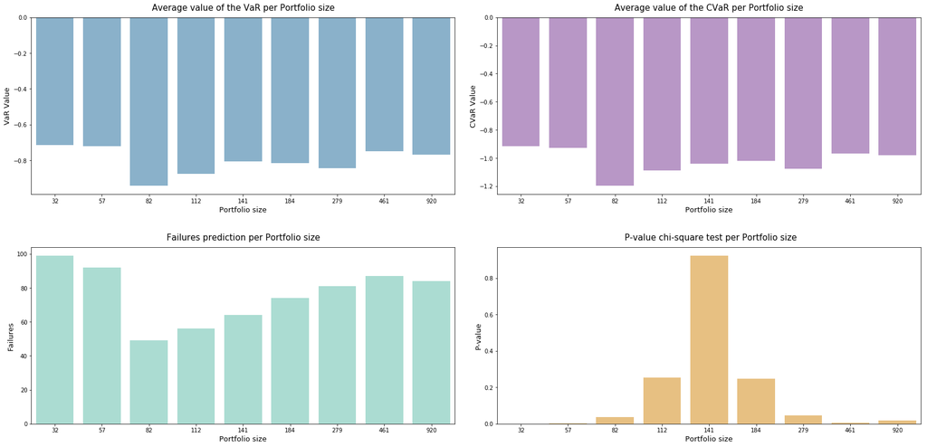

```python
plt.figure(figsize=[25,20])

# plot the VaR
plt.subplot(221)
plt.title("Average value of the VaR per Portfolio size", fontsize=15, y=1.02)
ax = sns.barplot(x="num_stocks", y="value_at_risk", data=df, color="#7FB3D5")
plt.xlabel("Portfolio size", fontsize=13)
plt.ylabel("VaR Value", fontsize=13)
# plot the CVaR
plt.subplot(222)
plt.title("Average value of the CVaR per Portfolio size", fontsize=15, y=1.02)
ax = sns.barplot(x="num_stocks", y="conditional_value_at_risk", data=df, color="#BB8FCE")
plt.xlabel("Portfolio size", fontsize=13)
plt.ylabel("CVaR Value", fontsize=13)
# plot the failures
plt.subplot(223)
plt.title("Failures prediction per Portfolio size", fontsize=15, y=1.02)
ax = sns.barplot(x="num_stocks", y="failures", data=df, color="#A3E4D7",)
plt.xlabel("Portfolio size", fontsize=13)
plt.ylabel("Failures", fontsize=13)
# plot p-value
plt.subplot(224)
plt.title(" P-value chi-square test per Portfolio size", fontsize=15, y=1.02)
ax = sns.barplot(x="num_stocks", y="p_value", data=df, color="#F8C471")
plt.xlabel("Portfolio size", fontsize=13)
plt.ylabel("P-value", fontsize=13)

plt.subplots_adjust(left=None, bottom=1.5, right=1, top=2, wspace=0.1, hspace=0.3)
```

### Comment

We have tried to run simulations with a different number of Stocks to see how this would have impacted the VaR and the CVaR of the portfolio. Please note that we are considering the average loss: so, also the VaR and CVaR are averaged over the portfolio size. Considering the results, there is an initial increase in the average Risk, then the pattern is quite irregular as the size of the portfolio increases. A possible explanation of this resides in the type of stocks we include in the portfolio. Maybe among the first selected, there are some which are performing well. Instead, while increasing the portfolio we include stocks which may have a negative trend. This is a possible explanation of the increase of the VaR.  
A final observation must be done for the failures and the p-value. We can notice from the table and the graphs that the p-value reaches a maximum for 141 stocks. The Null Hypothesis for the VaR is accepted in the case of 112, 141 and 184 stocks. If compared with the failures there is no a direct relation between these ones and the p-values. Indeed, for 82 stocks we have the lowest failures but the model is not accepted due to the p-value is under 0.05. If we observe the VaR, this is also the number of stocks for which is higher. A possible reason we can give is that the model is overestimating the loss and so the failures are reduced, but the Kupiec Test is not passed. In the case of a large amount of stocks the model is not able to estimate well the risk and so also the failures increase.  
We investigate the p-value further, for now, assuming the previous knowledge we can explain this as a result of including stocks which are used to define the two indeces of the market: the **NASDAQ Composite** and **S&P500**. In that case, the inclusion of the related stocks in the portfolio, allowed for a better estimation of the risk thanks to the correlation between the stocks and the market factors.

### Question 10

In the previous questions, we used the normal distributions to sample the factors returns. Try to study how results vary when selecting other probability distributions: our goal is to improve the result of our MCS.

### Model improvements

We want to try different improvements for our MCS, including:

- different regression model
- different distribution assumption for the market conditions

## Regression model

We used an OLS model assuming the linearity and [homoscedasticity](https://en.wikipedia.org/wiki/Homoscedasticity) of the observations, which may not be the case for stocks like it is suggested [here](https://www.investopedia.com/terms/h/heteroskedastic.asp): some tests will be run to prove such assumption [[link](http://www.statsmodels.org/dev/diagnostic.html)].  
So, we are now going to prove the heteroscedasticity of our observations: if the tests pass, OLS is no more the BLUE (best linear unbiased estimator) and we move to a regression model such as GLS (which is better suited for heteroskedastic error patterns).

```python
from statsmodels.stats.diagnostic import het_breuschpagan

# select a good portion of the stocks and prepare them. Note: the trimAndClen function is applied
stocks = prepareStocks(stock_folder, 200, start, end, verbose=True)
stocks_returns = list(map(twoWeekReturns, stocks))

rejected = 0
for stk in stocks_returns:
    lm, lm_pvalue, fvalue, f_pvalue = het_breuschpagan(stk, factor_columns)
    # test if the null hypoyhesis is rejected
    if f_pvalue < 0.05:
        rejected += 1

print("Percentage of rejected test for the Null Hypothesis (homoscedasticity) over {0!s} instrumnets: {1:.2f}%"
      .format(len(stocks_returns), rejected * 100 /len(stocks_returns) ))
```

```
Searching for the wanted number of stocks!
Cleaned 16 stocks due to their number of missing samples > 60
Total number of stocks prepared: 184
Percentage of rejected test for the Null Hypothesis (homoscedasticity) over 184 instrumnets: 90.22%
```

### Comments

The Breush-Pagan test performs a statistic that is chi-squared distributed. The p-value is the result of the chi-squared test where the null hypothesis is rejected for p-value < 0.05. We can so reject the null hypothesis $H_{0}$ that the observations are homoscedasticity if we obtain a p-value which is lower. The above script compute the percentage of instrumnets observed which didn't pass the test and for which we can reject the homoscedasticity.

```python
def estimateGLS(y, x):
    """Function to return the parameters for a regression model evaluated using Generalized Least Squares"""
    return sm.regression.linear_model.GLS(y, x).fit().params
```

We try different experiments to see if the GLS represents really an advantage for improving the model. We run the MCS for different number of samples.

```python
start = datetime(year=2009, month=1, day=23)
end = datetime(year=2014, month=1, day=23)
parallelism = 12
numb_trials = 10000
numb_stocks = [30, 60, 90, 120]
dim = 1
results = {
            "num_stocks": [],
            "value_at_risk": [],
            "conditional_value_at_risk": [],
            "var_confidence_interval": [],
            "cvar_onfidence_interval": [],
            "regression": [],
            "p_value": [],
            "failures": []
          }

for numb_stock in numb_stocks:
    for regres, name_m in zip([estimateParams, estimateGLS], ["OLS", "GLS"]):
        results["regression"].append(name_m)
        print("Starting MCS with regression model: {0} and number of stocks: {1!s}".format(name_m, numb_stock))
        runCompleteExperimentGeneral(numb_stock, start, end, regres, np.random.multivariate_normal , [factorMeans, factorCov],
                                     results, numb_trials, parallelism, verbose=False, prep_stock_verbose=False)
print("\nFinished!")
```

```
Starting MCS with regression model: OLS and number of stocks: 30
Starting MCS with regression model: GLS and number of stocks: 30
Starting MCS with regression model: OLS and number of stocks: 60
Starting MCS with regression model: GLS and number of stocks: 60
Starting MCS with regression model: OLS and number of stocks: 90
Starting MCS with regression model: GLS and number of stocks: 90
Starting MCS with regression model: OLS and number of stocks: 120
Starting MCS with regression model: GLS and number of stocks: 120

Finished!
```

```python
df = pd.DataFrame(data=results)
df = df[["num_stocks", "value_at_risk", "conditional_value_at_risk",  "regression", "failures", "p_value" ]]
df
```

|  | num_stocks | value_at_risk | conditional_value_at_risk | regression | failures | p_value |
| --- | --- | --- | --- | --- | --- | --- |
| 0 | 32 | -0.703487 | -0.917525 | OLS | 103 | 0.000007 |
| 1 | 32 | -0.710607 | -0.913929 | GLS | 101 | 0.000018 |
| 2 | 57 | -0.711870 | -0.914779 | OLS | 92 | 0.001049 |
| 3 | 57 | -0.695424 | -0.892729 | GLS | 95 | 0.000298 |
| 4 | 82 | -0.946198 | -1.195845 | OLS | 48 | 0.025478 |
| 5 | 82 | -0.943699 | -1.185677 | GLS | 49 | 0.036217 |
| 6 | 112 | -0.861293 | -1.091693 | OLS | 58 | 0.381318 |
| 7 | 112 | -0.853811 | -1.076902 | GLS | 61 | 0.629368 |

[figure not shown]

```python
plt.figure(figsize=[15,7])
# plot the VaR
plt.subplot(121)
plt.title("P-value comparisons with different regressions", fontsize=15, y=1.03)
sns.barplot(x="num_stocks", y="p_value", hue="regression", data=df, color="#7FB3D5")
plt.xlabel("Regression method", fontsize=13)
plt.ylabel("p_value", fontsize=13)

plt.subplot(122)
plt.title("Failures comparisons with different regressions", fontsize=15, y=1.03)
sns.barplot(x="num_stocks", y="failures", hue="regression", data=df, color="#7FB3D5")
plt.xlabel("Regression method", fontsize=13)
plt.ylabel("Failures", fontsize=13)

plt.show()
plt.subplots_adjust(left=None, bottom=1.5, right=1, top=2, wspace=0.2, hspace=None)
```

## Distribution for the Market Conditions

Taking inspiration from [[link]](http://econpapers.wiwi.kit.edu/downloads/KITe_WP_30.pdf) we want to try a different distribution which is fat-tailed. As suggested, the **Student's t Distribution** can be chosen, due to the fact it is a common fat-tailed one. As suggested, a degree of freedom (DOF) value set to 5 can be a good general choice, but it is preferred to tailor this value because fixing it a priori can be a limitation.  
What we do now is to compare the distribution obtained using the Kernel Density Estimator over the *factorsReturns* samples and the Student's t one. To achieve this, we draw random samples (the same quantity we have for the market factors) from a multivariate Student's t distribution and we use the KDE to compare the results. The script was retrieven [[here]](http://pydoc.net/scikits.statsmodels/0.3.1/scikits.statsmodels.sandbox.distributions.multivariate/) and modified when we need to return one value only.

```python
#written by Enzo Michelangeli, style changes by josef-pktd
# Student's T random variable
def multivariate_t_rvs(m, S, df=np.inf, n=1):
    '''generate random variables of multivariate t distribution
    Parameters
    ----------
    m : array_like
        mean of random variable, length determines dimension of random variable
    S : array_like
        square array of covariance  matrix
    df : int or float
        degrees of freedom
    n : int
        number of observations, return random array will be (n, len(m))
    Returns
    -------
    rvs : ndarray, (n, len(m))
        each row is an independent draw of a multivariate t distributed
        random variable
    '''

    m = np.asarray(m)
    d = len(m)
    if df == np.inf:
        x = 1.
    else:
        x = np.random.chisquare(df, n)/df

    z = np.random.multivariate_normal(np.zeros(d),S,(n,))

    # same output format as random.multivariate_normal
    if n == 1:
        # modified to return only one value
        res = (m + z/np.sqrt(x)).flatten()
        return res
    else:
        return m + z/np.sqrt(x)[:,None]
```

### Test the distribution

Now we test the student's t distribution with different degrees of freedom. To avoid to many plots, we have tried different ranges for the parameter, at the and the best results where retrieven when the DF was closo to the propose value in the paper.  
To not be limited, now we run some experiments with values for the DF in the range from 2 to 20, focusing more on the values close to 5.

```python
start = datetime(year=2009, month=1, day=23)
end = datetime(year=2014, month=1, day=23)
parallelism = 12
numb_trials = 10000
numb_stocks = 30
# parameters for the distribution
df_values = [2, 4, 5, 6, 7, 8, 10, 15, 20]
dim = 1
results = {
            "num_stocks": [],
            "value_at_risk": [],
            "conditional_value_at_risk": [],
            "var_confidence_interval": [],
            "cvar_onfidence_interval": [],
            "df": df_values,
            "p_value": [],
            "failures": []
          }

for indx, df in enumerate(df_values):
        print("Starting t-student MCS with df: {0!s}".format(df))
        runCompleteExperimentGeneral(numb_stocks, start, end, estimateParams, multivariate_t_rvs,
                                     [factorMeans, factorCov, df, dim], results, numb_trials, parallelism,
                                     verbose=False, prep_stock_verbose=False)
        print("Finished!\n")
```

```
Starting t-student MCS with df: 2
Finished!

Starting t-student MCS with df: 4
Finished!

Starting t-student MCS with df: 5
Finished!

Starting t-student MCS with df: 6
Finished!

Starting t-student MCS with df: 7
Finished!

Starting t-student MCS with df: 8
Finished!

Starting t-student MCS with df: 10
Finished!

Starting t-student MCS with df: 15
Finished!

Starting t-student MCS with df: 20
Finished!
```

```python
df = pd.DataFrame(data=results)
df = df[[ "value_at_risk", "var_confidence_interval", "conditional_value_at_risk", "cvar_onfidence_interval", "df", "failures", "p_value" ]]
df
```

|  | value_at_risk | var_confidence_interval | conditional_value_at_risk | cvar_onfidence_interval | df | failures | p_value |
| --- | --- | --- | --- | --- | --- | --- | --- |
| 0 | -1.521490 | (-1.4736301033873493, -1.5727250407843358) | -7.402474 | (-9.055541316824243, -6.611387278339706) | 2 | 10 | 5.935540e-18 |
| 1 | -0.986826 | (-0.9864941439299267, -0.9968983395449091) | -1.537773 | (-1.574996811614745, -1.589288656314101) | 4 | 48 | 2.547820e-02 |
| 2 | -0.942037 | (-0.9333517031925618, -0.9064666537805245) | -1.389839 | (-1.3761254275214378, -1.4017204665116885) | 5 | 52 | 9.277652e-02 |
| 3 | -0.859977 | (-0.8427037357353419, -0.8550155837890558) | -1.265652 | (-1.2468425952382207, -1.2796315896611803) | 6 | 63 | 8.226854e-01 |
| 4 | -0.855221 | (-0.8782149646687155, -0.8617273780266951) | -1.233303 | (-1.2368371255203228, -1.239583130246373) | 7 | 64 | 9.236774e-01 |
| 5 | -0.832168 | (-0.8184484999611304, -0.830013698436204) | -1.205036 | (-1.1955091409819292, -1.1981922932929536) | 8 | 68 | 6.809505e-01 |
| 6 | -0.820237 | (-0.8255002522924102, -0.8201380955300217) | -1.134444 | (-1.1032846956195832, -1.1469982030579706) | 10 | 74 | 2.483840e-01 |
| 7 | -0.779580 | (-0.7862868964926053, -0.7728149564695572) | -1.040976 | (-1.0180414536537399, -1.0966014823376715) | 15 | 81 | 4.577388e-02 |
| 8 | -0.731640 | (-0.7178221619925134, -0.7509171407276998) | -0.979516 | (-0.9361485776724158, -0.9972511961914636) | 20 | 96 | 1.914714e-04 |

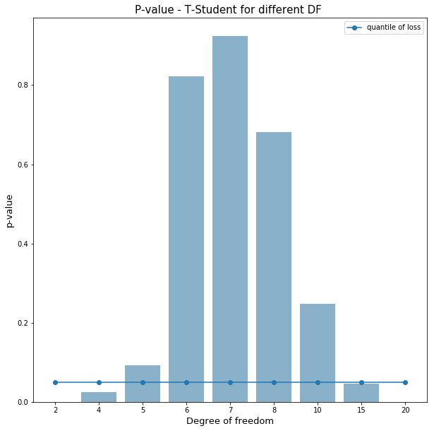

```python
plt.figure(figsize=[10,10])
# plot the VaR
plt.title("P-value - T-Student for different DF ", fontsize=15)
sns.barplot(x="df", y="p_value", data=df, color="#7FB3D5")
plt.plot([0.05]*len(df_values), "o-", label="quantile of loss")
plt.xlabel("Degree of freedom", fontsize=13)
plt.ylabel("p-value", fontsize=13)
plt.legend()
```

### Comment

Now we compare the emprical distributions of the *marketfactors* with the student's t with the best degrees of freedom we have obtained before.

```python
# different degrees of freedom (from the best observed)
dfs = [ 5, 6, 7, 8]

# use the factorMeans and factorCov to produce samples from a multivariate Student's t distribution
samples_vector = [factorsReturns]

for df in dfs:
    result = multivariate_t_rvs(factorMeans, factorCov, df, len(factorsReturns[0]))
    # the result is a len(factorFeatures) by 4 matrix, we need to invert
    samples_vector.append(transpose(result))
```

```python
names = ["Crude Oil", "US Bond", "GSPC", "IXIC"]
def plotMyDistribution(samples_vector, indx):
    plt.subplot(220+indx+1)
    for i, samples in enumerate(samples_vector):
        domain, density = computeKerneDensity(samples)
        if i != 0:
            plt.plot(domain, density, "--")
        else:
            plt.plot(domain, density)

    plt.title("KDE - Probability Distribution for {0} Market Factor".format(names[indx]), fontsize=20, y=1.03)
    plt.xlabel("Value", fontsize=15)
    plt.ylabel("Probability", fontsize=15)
    plt.legend(["Empiric", *["DF: " + str(x) for x in dfs]], fontsize=15)
    plt.grid()
```

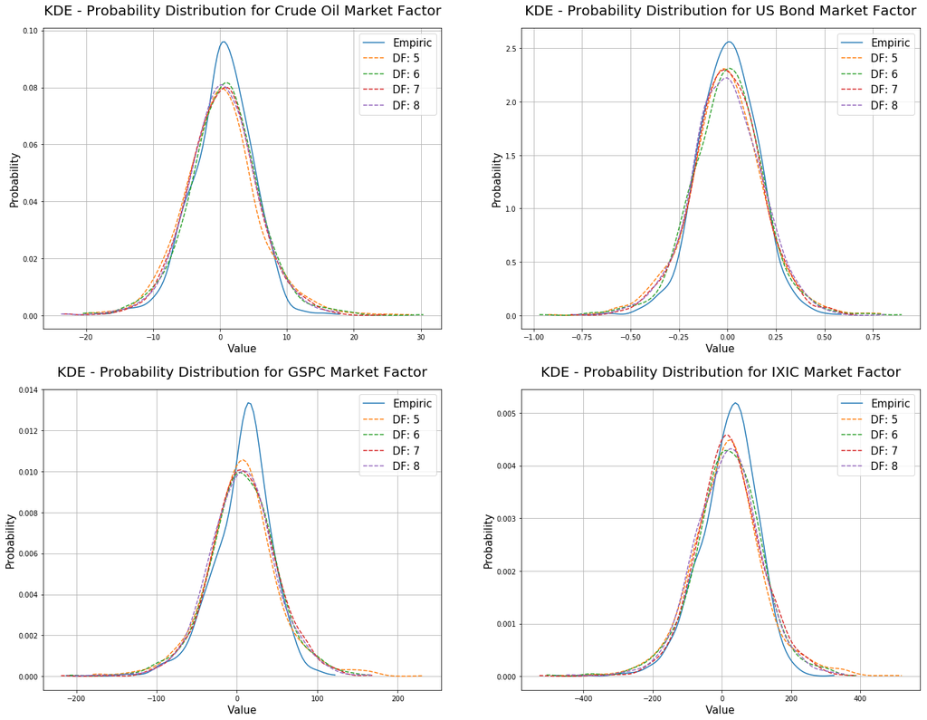

```python
plt.figure(figsize=[20,12])

for indx, name in enumerate(names):
    plotMyDistribution([x[indx] for x in samples_vector], indx)

plt.subplots_adjust(left=None, bottom=0.9, right=1, top=2, wspace=None, hspace=0.2)
plt.show()
```

From the above plots we can see how the different student's t distributions with different degrees of freedom fit the distributuion of the four market factors.

## Standard & Poors' Portfolio

Based on the infromation we obtained for the Market Indexes, we know that the S&P500 index is based on 500 stocks from major companies in U.S. which informaion is available in this [link](https://en.wikipedia.org/wiki/List_of_S%26P_500_companies). We have exported the html and derived a csv file in order to work with it. The idea is to see how the model performs if we build the portfolio selecting the stocks from the ones listed in the table. Once we load the table, we use pandas dataFrames to filter the ones which we have as time series data. Once we have the *Ticker Symbols* of the stocks we load them to then apply the MCS we have developed so far. We will use this also as a benchmark between the different improvments we have applied to the original MCS.

```python
# load and show the first 10 S&P stocks information
stand_poors_df = pd.read_csv("stand_and_poors_500.csv", sep=",", header="infer")
stand_poors_df = stand_poors_df[["Ticker symbol", "Security", "GICS Sector", "GICS Sub Industry"]]
stand_poors_df[:5]
```

|  | Ticker symbol | Security | GICS Sector | GICS Sub Industry |
| --- | --- | --- | --- | --- |
| 0 | AAP | Advance Auto Parts | Consumer Discretionary | Automotive Retail |
| 1 | AMZN | Amazon.com Inc. | Consumer Discretionary | Internet & Direct Marketing Retail |
| 2 | APTV | Aptiv Plc | Consumer Discretionary | Auto Parts & Equipment |
| 3 | AZO | AutoZone Inc | Consumer Discretionary | Specialty Stores |
| 4 | BBY | Best Buy Co. Inc. | Consumer Discretionary | Computer & Electronics Retail |

Now, we filter only those for which we have the time series saved as separate file.

```python
# load the files sotcks names to retrieve the Ticker symbol of the stocks
files = [f.replace(".csv", "") for f in listdir(stock_folder) if isfile(join(stock_folder, f))]
# filter the S&P500 stocks with the ones we have as data
stand_poors_df_owned = stand_poors_df.loc[stand_poors_df["Ticker symbol"].isin(files)]
print("Total number of stocks from S&P500 index is: {0!s}\n".format(len(stand_poors_df_owned["Ticker symbol"])))
stand_poors_df_owned[:5]
```

```
Total number of stocks from S&P500 index is: 118
```

|  | Ticker symbol | Security | GICS Sector | GICS Sub Industry |
| --- | --- | --- | --- | --- |
| 1 | AMZN | Amazon.com Inc. | Consumer Discretionary | Internet & Direct Marketing Retail |
| 10 | CHTR | Charter Communications | Consumer Discretionary | Cable & Satellite |
| 12 | CMCSA | Comcast Corp. | Consumer Discretionary | Cable & Satellite |
| 15 | DISCA | Discovery Inc. Class A | Consumer Discretionary | Cable & Satellite |
| 16 | DISCK | Discovery Inc. Class C | Consumer Discretionary | Cable & Satellite |

We have 118 stocks from the S&P500 index. The next step is to loead the stocks and perform MCSs to see the results in the case we decide to base our portfolio using only these stocks.

```python
# prepare S&P files
stocks_symb = stand_poors_df_owned[["Ticker symbol"]]
stocks_symb = list(stocks_symb.values[:, 0])
stand_poors_stock_files = [ stock_folder + "/" + stock + ".csv" for stock in stocks_symb ]
```

```python
## PREPARE STANDARD AND POORS STOCKS ##
raw_stocks = [processStockFile(f) for f in stand_poors_stock_files]
raw_stocks = list(filter(lambda instrument: len(instrument) > number_of_years * 260, raw_stocks))
stocks = trimAndClean(raw_stocks, start, end, threshold=60, verbose=True)
stocks_returns = list(map(twoWeekReturns, stocks))
factors_returns = list(map(twoWeekReturns, factors))
```

```
Cleaned 4 stocks due to their number of missing samples > 60
```

```python
start = datetime(year=2009, month=1, day=23)
end = datetime(year=2014, month=1, day=23)
parallelism = 12
numb_trials = 10000
numb_stocks = len(stocks_returns)
# parameters for the distribution
df_values = [15, 20, 22, 24, 26, 28, 30, 35, 40, 45]
dim = 1
results = {
            "num_stocks": [],
            "value_at_risk": [],
            "conditional_value_at_risk": [],
            "var_confidence_interval": [],
            "cvar_onfidence_interval": [],
            "df": [],
            "regression": [],
            "p_value": [],
            "failures": []
          }

for regres, name_m in zip([estimateParams, estimateGLS], ["OLS", "GLS"]):
        print("Starting MCSs - students t various df - model: {0} ".format(name_m))
        for df in df_values:
            results["regression"].append(name_m)
            results["df"].append(df)
            runCompleteExperimentGeneral(numb_stocks, start, end, regres, multivariate_t_rvs,
                                         [factorMeans, factorCov, df, dim], results, numb_trials, parallelism,
                                         verbose=False, prep_stock_verbose=False, load_stocks=False)
print("Finished!\n")
```

```
Starting MCSs - students t various df - model: OLS
Starting MCSs - students t various df - model: GLS
Finished!
```

```python
df = pd.DataFrame(data=results)
df = df[[ "regression", "df", "failures", "p_value" ]]
df[:5]
```

|  | regression | df | failures | p_value |
| --- | --- | --- | --- | --- |
| 0 | OLS | 15 | 60 | 0.539957 |
| 1 | OLS | 20 | 65 | 0.974587 |
| 2 | OLS | 22 | 65 | 0.974587 |
| 3 | OLS | 24 | 65 | 0.974587 |
| 4 | OLS | 26 | 78 | 0.101199 |

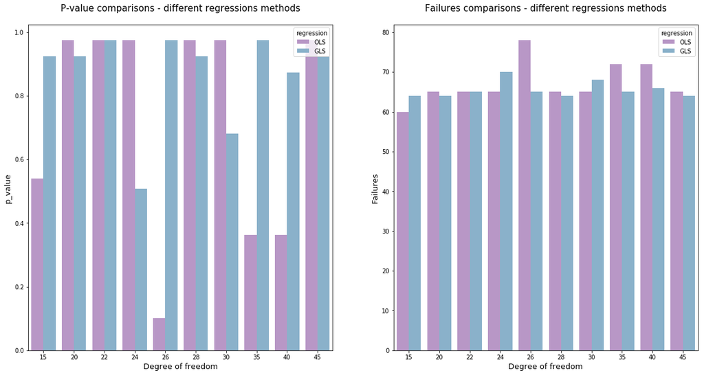

```python
plt.figure(figsize=[20,10])
# plot the VaR
plt.subplot(121)
plt.title("P-value comparisons - different regressions methods", fontsize=15, y=1.03)
sns.barplot(x="df", y="p_value", hue="regression", data=df, palette=["#BB8FCE", "#7FB3D5"])
plt.xlabel("Degree of freedom", fontsize=13)
plt.ylabel("p_value", fontsize=13)

plt.subplot(122)
plt.title("Failures comparisons - different regressions methods", fontsize=15, y=1.03)
sns.barplot(x="df", y="failures", hue="regression", data=df, palette=["#BB8FCE", "#7FB3D5"])
plt.xlabel("Degree of freedom", fontsize=13)
plt.ylabel("Failures", fontsize=13)

plt.show()
plt.subplots_adjust(left=None, bottom=1.5, right=1, top=2, wspace=0.2, hspace=None)
```

### Comments

We can notice from the plots that the best **p_value** of 0.974587 is associated with different degrees of freedom for the student's t distribution. We recall that we are using only stocks which belongs to the *Standard and Poors'* index. We took advantage of the simulation to try the two methods for the regression. It's possible to see how the GLS sometimes outperforms OLS, while in other cases the OLS performs better. In general, there is no real advantage of using GLS instead of OLS with this portfolio, due to we can reach the same p_value searching for the best parameters for the student's t distribution.

# Analysis of the stocks we own

We analysize now the stocks we have. Thanks to the data we used before we can classify the stocks based on their Sector or Industry. We wont to see which ones are more correlated to our facto market.

```python
stocks_info_df = pd.read_csv("stocks_info.csv", sep=",", header="infer")
# rename the index and the columns
stocks_info_df.columns = ["Ticker symbol", "Security", "GICS Sector", "GICS Sub Industry"]
# filter the NaN values
stocks_info_df = stocks_info_df[~stocks_info_df.Security.isnull()]
stocks_info_df[:10]
```

|  | Ticker symbol | Security | GICS Sector | GICS Sub Industry |
| --- | --- | --- | --- | --- |
| 0 | AAL | American Airlines Group Inc. | Passenger Airlines | Transportation/Logistics |
| 1 | APRI | Apricus Biosciences Inc. | Pharmaceuticals | Health Care/Life Sciences |
| 3 | CJJD | China Jo-Jo Drugstores Inc. | Drug Retail | Retail/Wholesale |
| 6 | GBCI | Glacier Bancorp Inc. | Banking | Financial Services |
| 7 | HTHT | China Lodging Group Ltd. | Hotels | Leisure/Arts/Hospitality |
| 8 | KFFB | Kentucky First Federal Bancorp | Banking | Financial Services |
| 9 | MERC | Mercer International Inc. | Paper/Pulp | Basic Materials/Resources |
| 10 | NTRI | Nutrisystem Inc. | Consumer Services | Business/Consumer Services |
| 11 | PGC | Peapack-Gladstone Financial Corp. | Banking | Financial Services |
| 12 | RELV | Reliv International Inc. | Pharmaceuticals | Health Care/Life Sciences |

```python
stocks_industry = stocks_info_df.groupby("GICS Sub Industry").count()
df = stocks_industry[["Security"]].sort_values(by=["Security"], ascending=False)
df[:10]
```

| GICS Sub Industry | Security |
| --- | --- |
| Financial Services | 423 |
| Health Care/Life Sciences | 399 |
| Technology | 288 |
| Business/Consumer Services | 158 |
| Industrial Goods | 157 |
| Consumer Goods | 103 |
| Retail/Wholesale | 81 |
| Real Estate/Construction | 77 |
| Companies on the Energy Service | 69 |
| Leisure/Arts/Hospitality | 64 |

```python
# extract the list of the different industries
industries = df.index.values.tolist()
industry_stocks = {}

for industry in industries:
    # extract only the stocks with the selected industry type
    stock_info = stocks_info_df.loc[stocks_info_df["GICS Sub Industry"] == industry]
    # retrieve only the ticker symbol
    stocks_symb = stock_info[["Ticker symbol"]]
    # cast to list
    stocks_symb = list(stocks_symb.values[:, 0])
    # recreate the path for the stock
    stand_poors_stock_files = [ stock_folder + "/" + stock + ".csv" for stock in stocks_symb ]
    # load the stocks
    raw_stocks = [processStockFile(f) for f in stand_poors_stock_files]
    # remove stocks with not enough days of records
    raw_stocks = list(filter(lambda instrument: len(instrument) > number_of_years * 260, raw_stocks))
    # trim and clean the stocks
    stocks = trimAndClean(raw_stocks, start, end, threshold=60, verbose=False)
    # extract only the value from the record for each stock
    stocks_data = [[entry[1] for entry in stock] for stock in stocks]
    # save the retrieved stocks in a dictionary
    industry_stocks[industry] = stocks_data
```

```python
# do the same for the factors
factor_data = [[entry[1] for entry in factor] for factor in factors]
```

### Comment

Once we have extracted all the values for the stocks and the factors, the idea is to show the correlation between each industry type of stocks and the four market factors. We are going to consider the average correlation obtained among all the stocks for a given industry and the market factors. To achieve so we retrieve a custom function which we have found [here](https://stackoverflow.com/questions/30143417/computing-the-correlation-coefficient-between-two-multi-dimensional-arrays/30145770#30145770).

```python
def generate_correlation_map(x, y):
    """Correlate each n with each m.

    Parameters
    ----------
    x : np.array
      Shape N X T.

    y : np.array
      Shape M X T.

    Returns
    -------
    np.array
      N X M array in which each element is a correlation coefficient.

    """
    mu_x = x.mean(1)
    mu_y = y.mean(1)
    n = x.shape[1]
    if n != y.shape[1]:
        raise ValueError('x and y must ' +
                         'have the same number of timepoints.')
    s_x = x.std(1, ddof=n - 1)
    s_y = y.std(1, ddof=n - 1)
    cov = np.dot(x,
                 y.T) - n * np.dot(mu_x[:, np.newaxis],
                                  mu_y[np.newaxis, :])
    return cov / np.dot(s_x[:, np.newaxis], s_y[np.newaxis, :])
```

```python
industries_correlations = {}

for k in industries:
    industries_correlations[k] = np.average(
                                    generate_correlation_map(np.array(industry_stocks[k]), np.array(factor_data)),
                                    axis = 0
                                )

correlation_df = pd.DataFrame(data=np.array(industries_correlations))
```

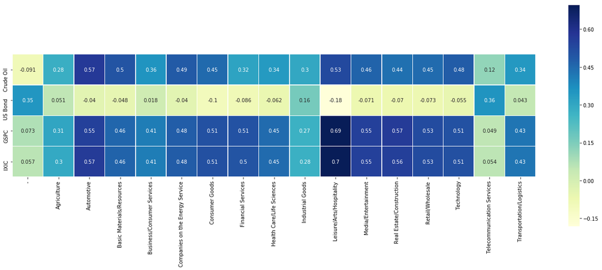

```python
plt.figure(figsize=[23,8])
heatmap(correlation_df, square=True, linewidths=.5, annot=True, cmap="YlGnBu", yticklabels=MARKET_FACTORS_NAMES)
```

### Comment

The heatmap represents the correlation between the stocks of different Industry types and the four market factors. What is of interest is the high correlation between the *Leisure/Arts/Hospitality* related stocks and the **NASDAQ Composite** index. We expected a higer correlation between this index and information technology related stocks. Indeed, there is a correlation but not as high as expected. Instead, this type of industry stocks are high correlated with the **NASDAQ** and the **S&P500**. Another interesting aspect which appears here is between the **US Bond** and the various indexes. Indeed seems that there is no correlation, a part for Telecommunication Services. Finally, an interesting correlation can be noticed between the *Automotive Industry* related stocks with the **Crude Oil**.

# References

- The example in section 2 is inspired from [this article](http://www.solver.com/monte-carlo-simulation-example).
- [Backtesting Value-at-Risk models](https://aaltodoc.aalto.fi/bitstream/handle/123456789/181/hse_ethesis_12049.pdf?sequence=1) (Kansantaloustiede, 2009) - (A good reference to study Backtesting).